# Homework Assignment #3: Categorical Predictors, Interactions Among Categorical Predictors, and Influential Data Points

EDUC/PSY 7610: Regression Analysis

Instructor: Jamison Fargo, PhD

April 10, 2023

Please complete the following exercises. You must include the code (as brief as possible) that was used to run each exercise along with the results. You may work in groups of 2 or 3 if you like, but each student should submit their own homework assignment. You will be able to upload your completed assignment to CANVAS. You may complete these exercises using BlueSky or R Studio (eg, script or R Markdown).

### Part I: Dummy & Contrast Coding

The data set entitled `Read.xlsx` contains end-of-year reading comprehension scores (`readcomp`) for 66 1st graders. Children were randomly assigned to one of three classrooms (`group`): CONTROL (`group` = 1; no reading comprehension instruction), READ1 (`group` = 2; standard reading comprehension instruction), and READ2 (`group` = 3; a new reading program). The goal of this research was to determine whether, in terms of end-of-year reading comprehension scores, READ2 was better than READ1, and if both READ1 and READ2 were better than the CONTROL condition. All students were tested at baseline and it was found that there were no significant differences in reading comprehension among the three groups. Please complete the following exercises using this data set:

```r
library(tidyverse)
library(car)
```

```r
library(carData)
library(ggpubr)
library(jtools)
library(broom)
library(cowplot)
library(lmtest)
library(gtsummary)
library(apaTables)
library(ppcor)
library(readxl)
library(dplyr)
library(emmeans)
```

1. Conduct a **simultaneous regression analysis using dummy coding** for the categorical study `group` variable. Use CONTROL as the reference group. Report your statistical results in a table (both omnibus and coefficients). Perform the contrast that was not made in the original dummy coding specification and include this result in your results (either as an added line in a single table or as two tables). Interpret the meaning of the slopes for the dummy code variables.

```r
reading <- read_excel("C:\\Users\\Rifatul Islam Himel\\Downloads\\Read.xlsx")
head(reading)
```

| id | readcomp | group |
| --- | --- | --- |
| 1 | 41 | 1 |
| 2 | 41 | 1 |
| 3 | 43 | 1 |
| 4 | 46 | 1 |
| 5 | 46 | 1 |
| 6 | 45 | 1 |

| id <dbl> | readcomp <dbl> | group <dbl> |  |  |
| --- | --- | --- | --- | --- |
| 1 | 41 | 1 |  |  |
| 2 | 41 | 1 |  |  |
| 3 | 43 | 1 |  |  |
| 4 | 46 | 1 |  |  |
| 5 | 46 | 1 |  |  |
| 6 | 45 | 1 |  |  |

6 rows

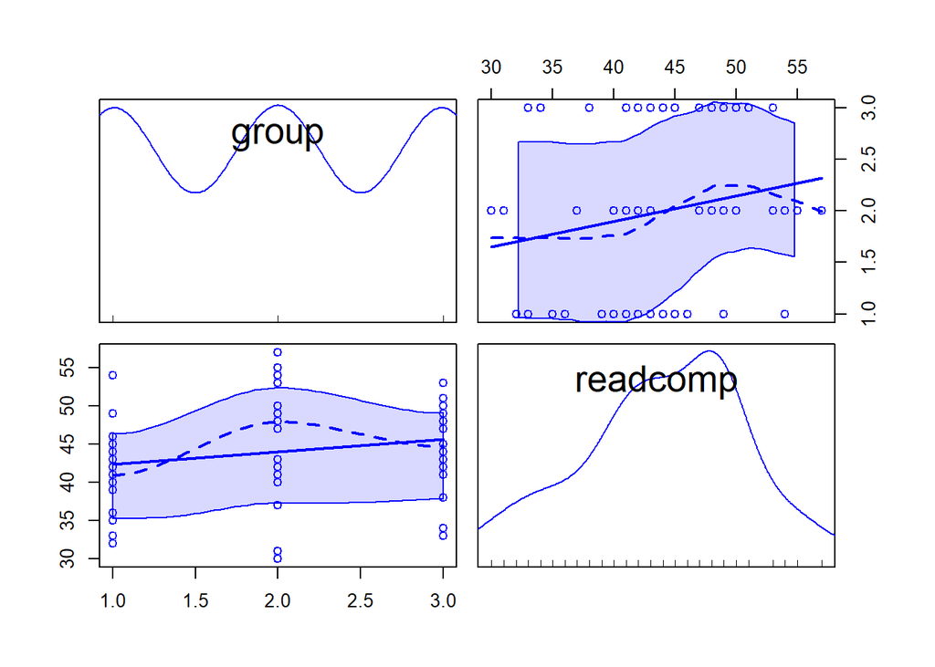

```r
scatterplotMatrix(~ group + readcomp, data = reading)
```

```r
lm.1 <- lm(readcomp ~ group, data=reading)
summ(lm.1)
```

```
## MODEL INFO:
## Observations: 66
## Dependent Variable: readcomp
## Type: OLS linear regression
##
## MODEL FIT:
## F(1,64) = 2.66, p = 0.11
## R² = 0.04
## Adj. R² = 0.02
##
## Standard errors: OLS
## ------------------------------------------------
##                      Est.   S.E.   t val.      p
## ----------------- ------- ------ -------- ------
## (Intercept)         40.79   2.14    19.09   0.00
## group                1.61   0.99     1.63   0.11
## ------------------------------------------------
```

### Using CONTROL as the reference group.Report your statistical results in a table (both omnibus and coefficients).

```r
reading$group_F<- factor(reading$group, labels=c('CONTROL','READ1','READ2'))
reading$group_F
```

```
##  [1] CONTROL CONTROL CONTROL CONTROL CONTROL CONTROL CONTROL CONTROL CONTROL
## [10] CONTROL CONTROL CONTROL CONTROL CONTROL CONTROL CONTROL CONTROL CONTROL
## [19] CONTROL CONTROL CONTROL CONTROL READ1   READ1   READ1   READ1   READ1
## [28] READ1   READ1   READ1   READ1   READ1   READ1   READ1   READ1   READ1
## [37] READ1   READ1   READ1   READ1   READ1   READ1   READ1   READ1   READ2
## [46] READ2   READ2   READ2   READ2   READ2   READ2   READ2   READ2   READ2
## [55] READ2   READ2   READ2   READ2   READ2   READ2   READ2   READ2   READ2
## [64] READ2   READ2   READ2
## Levels: CONTROL READ1 READ2
```

```r
contrasts(reading$group_F)
```

```
##         READ1 READ2
## CONTROL     0     0
## READ1       1     0
## READ2       0     1
```

```r
lm.d1 <- lm(readcomp ~ group_F, data=reading)
summ(lm.d1)
```

```
## MODEL INFO:
## Observations: 66
## Dependent Variable: readcomp
## Type: OLS linear regression
##
## MODEL FIT:
## F(2,63) = 4.48, p = 0.02
## R² = 0.12
## Adj. R² = 0.10
##
## Standard errors: OLS
## -------------------------------------------------
##                       Est.   S.E.   t val.      p
## ------------------ ------- ------ -------- ------
## (Intercept)          41.05   1.35    30.49   0.00
## group_FREAD1          5.68   1.90     2.98   0.00
## group_FREAD2          3.23   1.90     1.70   0.09
## -------------------------------------------------
```

```r
summary(lm.d1)
```

```
##
## Call:
## lm(formula = readcomp ~ group_F, data = reading)
##
## Residuals:
##     Min      1Q  Median      3Q     Max
## -16.727  -3.614   1.114   3.954  12.954
##
## Coefficients:
##              Estimate Std. Error t value Pr(>|t|)
## (Intercept)    41.045      1.346  30.490  < 2e-16 ***
## group_FREAD1    5.682      1.904   2.985  0.00404 **
## group_FREAD2    3.227      1.904   1.695  0.09498 .
## ---
## Signif. codes:  0 '***' 0.001 '**' 0.01 '*' 0.05 '.' 0.1 ' ' 1
##
## Residual standard error: 6.314 on 63 degrees of freedom
## Multiple R-squared:  0.1245, Adjusted R-squared:  0.09675
## F-statistic: 4.481 on 2 and 63 DF,  p-value: 0.01515
```

**Interpretation of the above table:**

The Estimate column in the output table shows the coefficients for the dummy-coded variables relative to the reference group (CONTROL). For example, the coefficient for READ1 is 5.68, which means that, on average, the effect of READ1 have 5.68 unit more than the CONTROL group (the reference group). Similarly, the coefficient for READ2 is 3.23, which means that, on average, he effect of READ2 have 3.23 unit more than the CONTROL group.

**Perform the contrast that was not made in the original dummy coding specification and include this result in your results.**

In dummy coding specification, CONTROL was taken as reference category. Now, I am changing the reference category and run the regression so that I can compare original dummy coding specification with customized dummy coding specification.

```r
contrasts(reading$group_F) <- contr.Treatment(levels(reading$group_F), base = 2)
contrasts(reading$group_F)
```

```
##         [T.CONTROL] [T.READ2]
## CONTROL           1         0
## READ1             0         0
## READ2             0         1
```

```r
lm.d2 <- lm(readcomp ~ group_F, data=reading)
summ(lm.d2)
```

```
## MODEL INFO:
## Observations: 66
## Dependent Variable: readcomp
## Type: OLS linear regression
##
## MODEL FIT:
## F(2,63) = 4.48, p = 0.02
## R² = 0.12
## Adj. R² = 0.10
##
## Standard errors: OLS
## -------------------------------------------------------
##                             Est.   S.E.   t val.      p
## ------------------------ ------- ------ -------- ------
## (Intercept)                46.73   1.35    34.71   0.00
## group_F[T.CONTROL]         -5.68   1.90    -2.98   0.00
## group_F[T.READ2]           -2.45   1.90    -1.29   0.20
## -------------------------------------------------------
```

```r
summary(lm.d2)
```

```
##
## Call:
## lm(formula = readcomp ~ group_F, data = reading)
##
## Residuals:
##     Min      1Q  Median      3Q     Max
## -16.727  -3.614   1.114   3.954  12.954
##
## Coefficients:
##                    Estimate Std. Error t value Pr(>|t|)
## (Intercept)          46.727      1.346  34.711  < 2e-16 ***
## group_F[T.CONTROL]   -5.682      1.904  -2.985  0.00404 **
## group_F[T.READ2]     -2.455      1.904  -1.289  0.20201
## ---
## Signif. codes:  0 '***' 0.001 '**' 0.01 '*' 0.05 '.' 0.1 ' ' 1
##
## Residual standard error: 6.314 on 63 degrees of freedom
## Multiple R-squared:  0.1245, Adjusted R-squared:  0.09675
## F-statistic: 4.481 on 2 and 63 DF,  p-value: 0.01515
```

```r
contrasts(reading$group_F) <- contr.Treatment(levels(reading$group_F), base = 3)
contrasts(reading$group_F)
```

```
##         [T.CONTROL] [T.READ1]
## CONTROL           1         0
## READ1             0         1
## READ2             0         0
```

```r
lm.d3 <- lm(readcomp ~ group_F, data=reading)
summ(lm.d3)
```

```
## MODEL INFO:
## Observations: 66
## Dependent Variable: readcomp
## Type: OLS linear regression
##
## MODEL FIT:
## F(2,63) = 4.48, p = 0.02
## R² = 0.12
## Adj. R² = 0.10
##
## Standard errors: OLS
## -------------------------------------------------------
##                             Est.   S.E.   t val.      p
## ------------------------ ------- ------ -------- ------
## (Intercept)                44.27   1.35    32.89   0.00
## group_F[T.CONTROL]         -3.23   1.90    -1.70   0.09
## group_F[T.READ1]            2.45   1.90     1.29   0.20
## -------------------------------------------------------
```

```r
summary(lm.d3)
```

```
##
## Call:
## lm(formula = readcomp ~ group_F, data = reading)
##
## Residuals:
##     Min      1Q  Median      3Q     Max
## -16.727  -3.614   1.114   3.954  12.954
##
## Coefficients:
##                    Estimate Std. Error t value Pr(>|t|)
## (Intercept)          44.273      1.346  32.888   <2e-16 ***
## group_F[T.CONTROL]   -3.227      1.904  -1.695    0.095 .
## group_F[T.READ1]      2.455      1.904   1.289    0.202
## ---
## Signif. codes:  0 '***' 0.001 '**' 0.01 '*' 0.05 '.' 0.1 ' ' 1
##
## Residual standard error: 6.314 on 63 degrees of freedom
## Multiple R-squared:  0.1245, Adjusted R-squared:  0.09675
## F-statistic: 4.481 on 2 and 63 DF,  p-value: 0.01515
```

**Interpretation:**

When reference category= CONTROL

The Estimate column in the output table shows the coefficients for the dummy-coded variables relative to the reference group (CONTROL). For example, the coefficient for READ1 is 5.68, which means that, on average, the effect of READ1 have 5.68 unit more than the CONTROL group (the reference group). Similarly, the coefficient for READ2 is 3.23, which means that, on average, he effect of READ2 have 3.23 unit more than the CONTROL group.  
When reference category= READ1

The Estimate column in the output table shows the coefficients for the dummy-coded variables relative to the reference group (READ1). For example, the coefficient for CONTROL is -5.68, which means that, on average, the effect of CONTROL have 5.68 unit less than the READ1 group (the reference group). Similarly, the coefficient for READ2 is -2.45, which means that, on average, he effect of READ2 have 2.45 unit less than the READ1 group.  
When reference category= READ2

The Estimate column in the output table shows the coefficients for the dummy-coded variables relative to the reference group (READ2). For example, the coefficient for CONTROL is -3.23, which means that, on average, the effect of CONTROL have 3.23 unit less than the READ2 group (the reference group). Similarly, the coefficient for READ1 is 2.45, which means that, on average, he effect of READ1 have 2.45 unit more than the READ2 group.  
Overall fit for the model remains the same, F(2,63) = 4.48, p = 0.02, R² = 0.12 and Adj. R² = 0.10 . For a categorical variable in regression analysis, R² = 0.12 means that the model explains 12% of the variance in the dependent variable that can be attributed to the categorical variable.  
2. Conduct a **simultaneous regression analysis using unweighted contrast coding** for the categorical study `group` variable. Perform the following contrasts:  
2.1. CONTROL vs. READ1 and READ2 combined;  
2.2. READ1 vs. READ2.

```r
reading$group_CC1 <- ifelse(reading$group_F=='READ1', -.3333,
                     ifelse(reading$group_F=='READ2', -.3333,
                            .6667))
reading$group_CC1
```

```
##  [1]  0.6667  0.6667  0.6667  0.6667  0.6667  0.6667  0.6667  0.6667  0.6667
## [10]  0.6667  0.6667  0.6667  0.6667  0.6667  0.6667  0.6667  0.6667  0.6667
## [19]  0.6667  0.6667  0.6667  0.6667 -0.3333 -0.3333 -0.3333 -0.3333 -0.3333
## [28] -0.3333 -0.3333 -0.3333 -0.3333 -0.3333 -0.3333 -0.3333 -0.3333 -0.3333
## [37] -0.3333 -0.3333 -0.3333 -0.3333 -0.3333 -0.3333 -0.3333 -0.3333 -0.3333
## [46] -0.3333 -0.3333 -0.3333 -0.3333 -0.3333 -0.3333 -0.3333 -0.3333 -0.3333
## [55] -0.3333 -0.3333 -0.3333 -0.3333 -0.3333 -0.3333 -0.3333 -0.3333 -0.3333
## [64] -0.3333 -0.3333 -0.3333
```

```r
contrasts(factor(reading$group_CC1))
```

```
##         0.6667
## -0.3333      0
## 0.6667       1
```

```r
reading$group_CC2 <- ifelse(reading$group_F=='READ1', -.50,
                     ifelse(reading$group_F=='READ2', .50,
                            0))
reading$group_CC2
```

```
##  [1]  0.0  0.0  0.0  0.0  0.0  0.0  0.0  0.0  0.0  0.0  0.0  0.0  0.0  0.0  0.0
## [16]  0.0  0.0  0.0  0.0  0.0  0.0  0.0 -0.5 -0.5 -0.5 -0.5 -0.5 -0.5 -0.5 -0.5
## [31] -0.5 -0.5 -0.5 -0.5 -0.5 -0.5 -0.5 -0.5 -0.5 -0.5 -0.5 -0.5 -0.5 -0.5  0.5
## [46]  0.5  0.5  0.5  0.5  0.5  0.5  0.5  0.5  0.5  0.5  0.5  0.5  0.5  0.5  0.5
## [61]  0.5  0.5  0.5  0.5  0.5  0.5
```

```r
contrasts(factor(reading$group_CC2))
```

```
##      0 0.5
## -0.5 0   0
## 0    1   0
## 0.5  0   1
```

3. Report the results of your analysis in a table. Interpret the meaning of the slopes for the contrast code variables.

```r
lm.c1 <- lm(readcomp ~ group_CC1+ group_CC2, data=reading)
summ(lm.c1)
```

```
## MODEL INFO:
## Observations: 66
## Dependent Variable: readcomp
## Type: OLS linear regression
##
## MODEL FIT:
## F(2,63) = 4.48, p = 0.02
## R² = 0.12
## Adj. R² = 0.10
##
## Standard errors: OLS
## ------------------------------------------------
##                      Est.   S.E.   t val.      p
## ----------------- ------- ------ -------- ------
## (Intercept)         44.02   0.78    56.63   0.00
## group_CC1           -4.45   1.65    -2.70   0.01
## group_CC2           -2.45   1.90    -1.29   0.20
## ------------------------------------------------
```

Intercept value 44.02 represents the adjusted grand mean for end-of-year reading comprehension scores, regardless of group. Slope for group_CC1 represents the adjusted mean difference in reading comprehension scores between CONTROL vs. READ1 and READ2 combined. Slope for group_CC2 represents the adjusted difference in reading comprehension scores between READ1 vs. READ2., ignoring CONTROL. Note: The overall fit is the same for dummy coding and contrast coding.

4. If you had to pick one type of coding method to BEST address the research questions above, which would you choose and why?  
   The choice between dummy coding and contrast coding depends on the specific research question and the nature of the categorical variable. Dummy coding is often the default method used in regression analysis and is appropriate when the research question focuses on differences between specific categories and a clear reference category can be identified. Contrast coding is more appropriate when the research question is focused on comparing groups of categories or testing specific hypotheses about the effects of the categorical variable.  
   The goal of this research was to determine whether, in terms of end-of-year reading comprehension scores, READ2 was better than READ1, and if both READ1 and READ2 were better than the CONTROL condition. From this, we can understand that this research question is focused on comparing groups of categories (READ1 vs READ2) and (READ1 & READ2 vs CONTROL).Therefore, I will choose contrast coding method instead of dummy coding method.

### Part II: Multiple Regression with Continuous & Categorical Predictors

Use the data set entitled `Angell` from the `carData` package in R. Regress moral integration (`moral`) on ethnic heterogeneity (`hetero`) centered, geographic mobility (`mobility`) centered, and region (`region`) (not centered, we don’t center categorical variables), using dummy variable coding with East as the reference group.

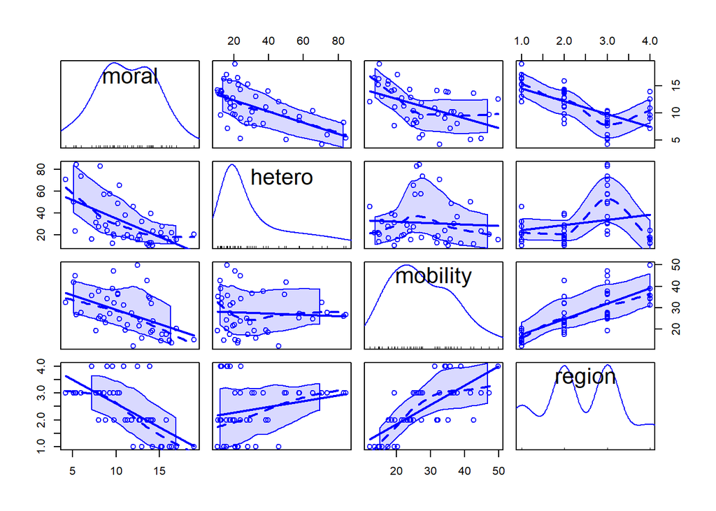

```r
Angell <- Angell %>%
  drop_na()

par(mar=c(5, 4, 4, 2))
scatterplotMatrix(~ moral + hetero + mobility + region, data = Angell)
```

```r
Angell$hetero_c <- scale(Angell$hetero, scale = FALSE)
Angell$mobility_c<-scale(Angell$mobility, scale = FALSE)
table(Angell$region)
```

```
##
##  E MW  S  W
##  9 14 14  6
```

```r
Angell$region_F <- factor(Angell$region, labels=c('E','MW','S', 'W'))
Angell$region_F
```

```
##  [1] E  E  E  E  MW E  E  MW E  MW MW W  MW MW E  MW MW W  E  MW MW MW W  MW W
## [26] W  MW MW W  S  S  S  S  S  S  S  S  S  S  S  S  S  S
## Levels: E MW S W
```

```r
contrasts(Angell$region_F)
```

```
##    MW S W
## E   0 0 0
## MW  1 0 0
## S   0 1 0
## W   0 0 1
```

```r
dim(Angell)
```

```
## [1] 43  7
```

```r
head(Angell)
```

|  | moral | hetero | mobility | region | hetero_c | mobility_c | region_F |
| --- | --- | --- | --- | --- | --- | --- | --- |
| Rochester | 19.0 | 20.6 | 15.0 | E | -10.772093 | -12.597674 | E |
| Syracuse | 17.0 | 15.6 | 20.2 | E | -15.772093 | -7.397674 | E |
| Worcester | 16.4 | 22.1 | 13.6 | E | -9.272093 | -13.997674 | E |
| Erie | 16.2 | 14.0 | 14.8 | E | -17.372093 | -12.797674 | E |
| Milwaukee | 15.8 | 17.4 | 17.6 | MW | -13.972093 | -9.997674 | MW |
| Bridgeport | 15.3 | 27.9 | 17.5 | E | -3.472093 | -10.097674 | E |

|  | moral <dbl> | hetero <dbl> | mobility <dbl> | region <fct> | hetero_c <dbl[,1]> | mobility_c <dbl[,1]> | region_F <fct> |
| --- | --- | --- | --- | --- | --- | --- | --- |
| Rochester | 19.0 | 20.6 | 15.0 | E | -10.772093 | -12.597674 | E |
| Syracuse | 17.0 | 15.6 | 20.2 | E | -15.772093 | -7.397674 | E |
| Worcester | 16.4 | 22.1 | 13.6 | E | -9.272093 | -13.997674 | E |
| Erie | 16.2 | 14.0 | 14.8 | E | -17.372093 | -12.797674 | E |
| Milwaukee | 15.8 | 17.4 | 17.6 | MW | -13.972093 | -9.997674 | MW |
| Bridgeport | 15.3 | 27.9 | 17.5 | E | -3.472093 | -10.097674 | E |

6 rows

```r
lm.2a1 <- lm(moral ~ hetero_c + mobility_c + region_F, data=Angell)
summ(lm.2a1)
```

```
## MODEL INFO:
## Observations: 43
## Dependent Variable: moral
## Type: OLS linear regression
##
## MODEL FIT:
## F(5,37) = 16.27, p = 0.00
## R² = 0.69
## Adj. R² = 0.65
##
## Standard errors: OLS
## ------------------------------------------------
##                      Est.   S.E.   t val.      p
## ----------------- ------- ------ -------- ------
## (Intercept)         14.06   1.10    12.81   0.00
## hetero_c            -0.07   0.03    -2.34   0.02
## mobility_c          -0.07   0.06    -1.14   0.26
## region_FMW          -2.52   1.08    -2.35   0.02
## region_FS           -4.59   1.83    -2.51   0.02
## region_FW           -3.86   1.63    -2.38   0.02
## ------------------------------------------------
```

1. Use a partial or incremental *F*-test ($R^2$-change test) from a **sequential regression** analysis to test the null hypothesis of no region effects (Hint: `anova(model1, model2)`). Report the results of both models in a table or tables (before and after adding the nominal predictor) as well as the result of the incremental *F*-test.

```r
lm.2a1 <- lm(moral ~ hetero_c + mobility_c + region_F, data=Angell)
summ(lm.2a1)
```

```
## MODEL INFO:
## Observations: 43
## Dependent Variable: moral
## Type: OLS linear regression
##
## MODEL FIT:
## F(5,37) = 16.27, p = 0.00
## R² = 0.69
## Adj. R² = 0.65
##
## Standard errors: OLS
## ------------------------------------------------
##                      Est.   S.E.   t val.      p
## ----------------- ------- ------ -------- ------
## (Intercept)         14.06   1.10    12.81   0.00
## hetero_c            -0.07   0.03    -2.34   0.02
## mobility_c          -0.07   0.06    -1.14   0.26
## region_FMW          -2.52   1.08    -2.35   0.02
## region_FS           -4.59   1.83    -2.51   0.02
## region_FW           -3.86   1.63    -2.38   0.02
## ------------------------------------------------
```

```r
lm.2a2 <- lm(moral ~ hetero_c + mobility_c, data=Angell)
summ(lm.2a2)
```

```
## MODEL INFO:
## Observations: 43
## Dependent Variable: moral
## Type: OLS linear regression
##
## MODEL FIT:
## F(2,40) = 33.25, p = 0.00
## R² = 0.62
## Adj. R² = 0.61
##
## Standard errors: OLS
## ------------------------------------------------
##                      Est.   S.E.   t val.      p
## ----------------- ------- ------ -------- ------
## (Intercept)         11.20   0.34    32.74   0.00
## hetero_c            -0.11   0.02    -6.39   0.00
## mobility_c          -0.19   0.04    -5.46   0.00
## ------------------------------------------------
```

```r
summary(lm.2a2)$r.squared
```

```
## [1] 0.6243781
```

```r
summary(lm.2a1)$r.squared
```

```
## [1] 0.6874096
```

```r
anova_table1<-anova(lm.2a2, lm.2a1)
print(anova_table1)
```

```
## Analysis of Variance Table
##
## Model 1: moral ~ hetero_c + mobility_c
## Model 2: moral ~ hetero_c + mobility_c + region_F
##   Res.Df    RSS Df Sum of Sq      F  Pr(>F)
## 1     40 201.27
## 2     37 167.49  3    33.774 2.4869 0.07562 .
## ---
## Signif. codes:  0 '***' 0.001 '**' 0.01 '*' 0.05 '.' 0.1 ' ' 1
```

```r
library(gtsummary)
lm.2a2.table <- tbl_regression(lm.2a2, intercept = TRUE,
                              label = list(hetero_c ~ "hetero", mobility_c ~ "mobility")) %>%
  add_glance_table(include = c(nobs, adj.r.squared, p.value), label = list(nobs ~ "N", p.value = "p-value"))
lm.2a2.table
```

| **Characteristic** | **Beta** | **95% CI**<sup>1</sup> | **p-value** |
| --- | --- | --- | --- |
| (Intercept) | 11 | 11, 12 | <0.001 |
| hetero | -0.11 | -0.14, -0.07 | <0.001 |
| mobility | -0.19 | -0.26, -0.12 | <0.001 |
| N | 43 |  |  |
| Adjusted R² | 0.606 |  |  |
| p-value | <0.001 |  |  |

<sup>1</sup> CI = Confidence Interval

```r
lm.2a1.table <- tbl_regression(lm.2a1, intercept = TRUE,
                              label = list(hetero_c ~ "hetero", mobility_c ~ "mobility",
                                           region_F ~ "US Region")) %>%
  add_glance_table(include = c(nobs, adj.r.squared, p.value), label = list(nobs ~ "N", p.value = "p-value"))
lm.2a1.table
```

| **Characteristic** | **Beta** | **95% CI**<sup>1</sup> | **p-value** |
| --- | --- | --- | --- |
| (Intercept) | 14 | 12, 16 | <0.001 |
| hetero | -0.07 | -0.12, -0.01 | 0.025 |
| mobility | -0.07 | -0.19, 0.05 | 0.3 |
| US Region |  |  |  |
| E | — | — |  |
| MW | -2.5 | -4.7, -0.35 | 0.024 |
| S | -4.6 | -8.3, -0.88 | 0.017 |
| W | -3.9 | -7.2, -0.57 | 0.023 |
| N | 43 |  |  |
| Adjusted R² | 0.645 |  |  |
| p-value | <0.001 |  |  |

<sup>1</sup> CI = Confidence Interval

```r
tbl_2_combine <-
  tbl_merge(
    list(lm.2a2.table, lm.2a1.table),
    tab_spanner = c("**Initial Model**", "**Full Model**")) %>%
  modify_table_body(
    ~.x %>%
      dplyr::arrange(
        row_type == "glance_statistic",
      )
  )
tbl_2_combine
```

| **Characteristic** | **Initial Model** **Beta** | **Initial Model** **95% CI**<sup>1</sup> | **Initial Model** **p-value** | **Full Model** **Beta** | **Full Model** **95% CI**<sup>1</sup> | **Full Model** **p-value** |
| --- | --- | --- | --- | --- | --- | --- |
| (Intercept) | 11 | 11, 12 | <0.001 | 14 | 12, 16 | <0.001 |
| hetero | -0.11 | -0.14, -0.07 | <0.001 | -0.07 | -0.12, -0.01 | 0.025 |
| mobility | -0.19 | -0.26, -0.12 | <0.001 | -0.07 | -0.19, 0.05 | 0.3 |
| US Region |  |  |  |  |  |  |
| E |  |  |  | — | — |  |
| MW |  |  |  | -2.5 | -4.7, -0.35 | 0.024 |
| S |  |  |  | -4.6 | -8.3, -0.88 | 0.017 |
| W |  |  |  | -3.9 | -7.2, -0.57 | 0.023 |
| N | 43 |  |  | 43 |  |  |
| Adjusted R² | 0.606 |  |  | 0.645 |  |  |
| p-value | <0.001 |  |  | <0.001 |  |  |

<sup>1</sup> CI = Confidence Interval

2. Leaving dummy-coded `region` in the same model as tested above, create prediction equations for `moral` for each `region` using what you know about the values used for dummy coding. These equations should look something like:  
   $(moral) = b_0 + b_1 ∗ hetero + b_2 ∗ mobility + b_3 ∗ region1 + b_4 ∗ region2 + b_5 ∗ region3$ …where the symbols $b_0$, $b_1$, $b_2$, etc. are replaced by actual numeric values and dummy coded values/coefficients are added to the equation to compute `moral` for each region.

```r
b0 <- coef(lm.2a1)[1]
b1 <- coef(lm.2a1)[2]
b2 <- coef(lm.2a1)[3]
b3 <- coef(lm.2a1)[4]
b4 <- coef(lm.2a1)[5]
b5 <- coef(lm.2a1)[6]

predicted_eqn <- paste("Predicted Equation:"," ", "moral = ", round(b0, 2), " - ", round(-b1, 2), "* hetero_c" , " - ", round(-b2, 2), "* mobility_c", " - ",round(-b3, 2), "* region_FMW" , " - ",round(-b4, 2), "* region_FS" , " - ",round(-b5, 2), "* region_FW"  , sep = "")

predicted_eqn
```

```
## [1] "Predicted Equation: moral = 14.06 - 0.07* hetero_c - 0.07* mobility_c - 2.52* region_FMW - 4.59* region_FS - 3.86* region_FW"
```

3. Compute the observed means (simple average) of moral for each `region` (Hint: these are just basic descriptive statistics, the means). Compare the observed means to the adjusted means (predicted or estimated marginal means) of `moral` for each `region` using the regression equations created above for each `region` in the previous exercise or the `emmeans()` R function. For either approach, you will need to plug in the means of `hetero` and `mobility` (0) in each regression equation.  
As there is an option to choose either `emmeans()` R function or compare manually, I have used `emmeans()` R function below:

```r
Angell %>%
  group_by(region_F) %>%
  summarise(moral = mean(moral))
```

| region_F | moral |
| --- | --- |
| E | 15.366667 |
| MW | 12.278571 |
| S | 7.735714 |
| W | 10.516667 |

| region_F <fct> | moral <dbl> |  |  |  |
| --- | --- | --- | --- | --- |
| E | 15.366667 |  |  |  |
| MW | 12.278571 |  |  |  |
| S | 7.735714 |  |  |  |
| W | 10.516667 |  |  |  |

4 rows

```r
lm.2a3 <- lm(moral ~ region_F, data=Angell)
summ(lm.2a3)
```

```
## MODEL INFO:
## Observations: 43
## Dependent Variable: moral
## Type: OLS linear regression
##
## MODEL FIT:
## F(3,39) = 23.19, p = 0.00
## R² = 0.64
## Adj. R² = 0.61
##
## Standard errors: OLS
## ------------------------------------------------
##                      Est.   S.E.   t val.      p
## ----------------- ------- ------ -------- ------
## (Intercept)         15.37   0.74    20.75   0.00
## region_FMW          -3.09   0.95    -3.25   0.00
## region_FS           -7.63   0.95    -8.04   0.00
## region_FW           -4.85   1.17    -4.14   0.00
## ------------------------------------------------
```

```r
emmeans(lm.2a1, pairwise ~ region_F, data = Angell, adjust = "none")
```

```
## $emmeans
##  region_F emmean    SE df lower.CL upper.CL
##  E         14.06 1.097 37    11.83     16.3
##  MW        11.53 0.660 37    10.19     12.9
##  S          9.47 0.978 37     7.49     11.4
##  W         10.19 1.000 37     8.17     12.2
##
## Confidence level used: 0.95
##
## $contrasts
##  contrast estimate   SE df t.ratio p.value
##  E - MW      2.525 1.08 37   2.348  0.0244
##  E - S       4.589 1.83 37   2.506  0.0168
##  E - W       3.865 1.63 37   2.378  0.0227
##  MW - S      2.064 1.39 37   1.490  0.1448
##  MW - W      1.340 1.20 37   1.115  0.2719
##  S - W      -0.725 1.37 37  -0.529  0.5997
```

```r
emmeans(lm.2a1, pairwise ~ region_F + mean(hetero_c) + mean(mobility_c), data = Angell, adjust = "none")
```

```
## $emmeans
##  region_F  hetero_c mobility_c emmean    SE df lower.CL upper.CL
##  E        -1.16e-15          0  14.06 1.097 37    11.83     16.3
##  MW       -1.16e-15          0  11.53 0.660 37    10.19     12.9
##  S        -1.16e-15          0   9.47 0.978 37     7.49     11.4
##  W        -1.16e-15          0  10.19 1.000 37     8.17     12.2
##
## Confidence level used: 0.95
##
## $contrasts
##  contrast
##  (E hetero_c-1.15790774901131e-15 mobility_c0) - (MW hetero_c-1.15790774901131e-15 mobility_c0)
##  (E hetero_c-1.15790774901131e-15 mobility_c0) - (S hetero_c-1.15790774901131e-15 mobility_c0)
##  (E hetero_c-1.15790774901131e-15 mobility_c0) - (W hetero_c-1.15790774901131e-15 mobility_c0)
##  (MW hetero_c-1.15790774901131e-15 mobility_c0) - (S hetero_c-1.15790774901131e-15 mobility_c0)
##  (MW hetero_c-1.15790774901131e-15 mobility_c0) - (W hetero_c-1.15790774901131e-15 mobility_c0)
##  (S hetero_c-1.15790774901131e-15 mobility_c0) - (W hetero_c-1.15790774901131e-15 mobility_c0)
##  estimate   SE df t.ratio p.value
##     2.525 1.08 37   2.348  0.0244
##     4.589 1.83 37   2.506  0.0168
##     3.865 1.63 37   2.378  0.0227
##     2.064 1.39 37   1.490  0.1448
##     1.340 1.20 37   1.115  0.2719
##    -0.725 1.37 37  -0.529  0.5997
```

### Part III: Interactions with Categorical Variables

Download the fictional data set entitled `Treatment` to complete the following exercises. This data set includes the following variables:

| Name | Description |
| --- | --- |
| `age` | participant age |
| `sex` | participant sex |
| `healthstatus` | participant status as healthy control or Alzheimer’s Disease |
| `drugtx` | participant status as having received a placebo, low dose, or high dose of an experimental drug |
| `mmse` | participant score on the Mini-Mental Status Examination |

1. Import the `Treatment` data into R and:

```r
treatment <- read_excel("C:\\Users\\Rifatul Islam Himel\\Downloads\\treatment.xlsx")
head(treatment)
```

| age | sex | healthstatus | drugtx | mmse |
| --- | --- | --- | --- | --- |
| 80 | 0 | Healthy | Placebo | 24.78988 |
| 85 | 0 | Healthy | Placebo | 24.88192 |
| 82 | 0 | Healthy | Placebo | 25.10903 |
| 80 | 0 | Healthy | Placebo | 24.92636 |
| 83 | 0 | Healthy | Placebo | 23.38845 |
| 79 | 0 | Healthy | Placebo | 24.11390 |

| age <dbl> | sex <dbl> | healthstatus <chr> | drugtx <chr> | mmse <dbl> |
| --- | --- | --- | --- | --- |
| 80 | 0 | Healthy | Placebo | 24.78988 |
| 85 | 0 | Healthy | Placebo | 24.88192 |
| 82 | 0 | Healthy | Placebo | 25.10903 |
| 80 | 0 | Healthy | Placebo | 24.92636 |
| 83 | 0 | Healthy | Placebo | 23.38845 |
| 79 | 0 | Healthy | Placebo | 24.11390 |

6 rows

1.1. For `healthstatus`: create a factor version of this variable using the `factor()` command and rename its levels “Alzheimer’s Disease” and “Control” using the associated `label()` command. Then, use the `factor()` command again to change the order of levels using the associated `levels()` command so that Control is first, serving as the reference category.

```r
treatment$healthstatus_F<- factor(treatment$healthstatus, labels=c('Alzheimer’s Disease','Control'))
treatment$healthstatus_F
```

```
##   [1] Control             Control             Control
##   [4] Control             Control             Control
##   [7] Control             Control             Control
##  [10] Control             Control             Control
##  [13] Control             Control             Control
##  [16] Control             Control             Control
##  [19] Control             Control             Control
##  [22] Control             Control             Control
##  [25] Control             Control             Control
##  [28] Control             Control             Control
##  [31] Control             Control             Control
##  [34] Control             Control             Control
##  [37] Control             Control             Control
##  [40] Control             Control             Control
##  [43] Control             Control             Control
```

[output cut: 186 more lines]

```r
contrasts(treatment$healthstatus_F)
```

```
##                     Control
## Alzheimer’s Disease       0
## Control                   1
```

```r
#treatment$healthstatus_F <- factor(treatment$healthstatus_F, levels = c("Control", "Alzheimer's Disease"))
#contrasts(treatment$healthstatus_F)

contrasts(treatment$healthstatus_F) <- contr.Treatment(levels(treatment$healthstatus_F), base = 1)
contrasts(treatment$healthstatus_F)
```

```
##                     [T.Control]
## Alzheimer’s Disease           0
## Control                       1
```

1.2. For `drugtx`: create a factor version of this variable using the `factor()` command and put its levels into the following order using the associated `levels()` command: Placebo, Low Dose, High Dose.

```r
treatment$drugtx_F <- factor(treatment$drugtx, levels = c('Placebo', 'Low Dose', 'High Dose'))

contrasts(treatment$drugtx_F)
```

```
##           Low Dose High Dose
## Placebo          0         0
## Low Dose         1         0
## High Dose        0         1
```

1.3. Center `age`.

```r
treatment$age <- scale(treatment$age, scale = FALSE)
```

1.4. Create a data set that only includes the following variables: `age` centered, `healthstatus` factor, `drugtx` factor, and `mmse`.

```r
treatment_data<- data.frame(treatment$age, treatment$healthstatus_F, treatment$drugtx_F, treatment$mmse)
head(treatment_data)
```

|  | treatment.age | treatment.healthstatus_F | treatment.drugtx_F | treatment.mmse |
| --- | --- | --- | --- | --- |
| 1 | -1.99 | Control | Placebo | 24.78988 |
| 2 | 3.01 | Control | Placebo | 24.88192 |
| 3 | 0.01 | Control | Placebo | 25.10903 |
| 4 | -1.99 | Control | Placebo | 24.92636 |
| 5 | 1.01 | Control | Placebo | 23.38845 |
| 6 | -2.99 | Control | Placebo | 24.11390 |

|  | treatment.age <dbl> | treatment.healthstatus_F <fct> | treatment.drugtx_F <fct> | treatment.mmse <dbl> |
| --- | --- | --- | --- | --- |
| 1 | -1.99 | Control | Placebo | 24.78988 |
| 2 | 3.01 | Control | Placebo | 24.88192 |
| 3 | 0.01 | Control | Placebo | 25.10903 |
| 4 | -1.99 | Control | Placebo | 24.92636 |
| 5 | 1.01 | Control | Placebo | 23.38845 |
| 6 | -2.99 | Control | Placebo | 24.11390 |

6 rows

```r
dim(treatment_data)
```

```
## [1] 600   4
```

1.5. Use the `contrasts()` command for the `healthstatus` and `drugtx` factor variables to ensure that they are properly set up for dummy coding, with the reference categories as indicated above (ie, Control and Placebo).

```r
contrasts(treatment_data$treatment.healthstatus_F)
```

```
##                     [T.Control]
## Alzheimer’s Disease           0
## Control                       1
```

```r
contrasts(treatment_data$treatment.drugtx_F)
```

```
##           Low Dose High Dose
## Placebo          0         0
## Low Dose         1         0
## High Dose        0         1
```

1.6. Initiate the `gtsummary` package and create a table of descriptive statistics using the following code:

```r
library(gtsummary)
treatment_data %>%
    tbl_strata(
      strata = treatment.healthstatus_F,
        .tbl_fun = ~ .x %>%
          tbl_summary(by = treatment.drugtx_F,
            label = list(treatment.age ~ "Age (centered)",
                         treatment.mmse ~ "Mini-Mental Status Examination"),
            digits = everything() ~ 1,
            type = list(treatment.age ~ "continuous"),
            statistic = all_continuous() ~ "{mean} ({sd})") %>%
    add_n(),
    .header = "**{strata}**, N = {n}"
)
```

| **Characteristic** | **Alzheimer’s Disease**, N = 300 **N** | **Alzheimer’s Disease**, N = 300 **Placebo**, N = 100<sup>1</sup> | **Alzheimer’s Disease**, N = 300 **Low Dose**, N = 100<sup>1</sup> | **Alzheimer’s Disease**, N = 300 **High Dose**, N = 100<sup>1</sup> | **Control**, N = 300 **N** | **Control**, N = 300 **Placebo**, N = 100<sup>1</sup> | **Control**, N = 300 **Low Dose**, N = 100<sup>1</sup> | **Control**, N = 300 **High Dose**, N = 100<sup>1</sup> |
| --- | --- | --- | --- | --- | --- | --- | --- | --- |
| Age (centered) | 300 | -0.3 (2.1) | 0.0 (2.0) | 0.2 (2.1) | 300 | 0.0 (2.2) | 0.1 (2.0) | 0.1 (1.9) |
| Mini-Mental Status Examination | 300 | 12.0 (1.8) | 15.0 (1.5) | 23.0 (1.2) | 300 | 24.9 (1.5) | 25.0 (1.4) | 25.5 (1.0) |

<sup>1</sup> Mean (SD)

2. Conduct a series of sequential multiple linear regression analyses that regress `mmse` scores on the following sets of predictor variables:
- `model 1: mmse ∼ age_c`
- `model 2: mmse ∼ age_c + healthstatus_F`
- `model 3: mmse ∼ age_c + healthstatus_F + drugtx_F`
- `model 4: mmse ∼ age_c + healthstatus_F + drugtx_F + age_c:healthstatus_F`
- `model 5: mmse ∼ age_c + healthstatus_F + drugtx_F + age_c:drugtx_F`
- `model 6: mmse ∼ age_c + healthstatus_F + drugtx_F + drugtx_F:healthstatus_F`

```r
lm.3a1 <- lm(treatment.mmse ~ treatment.age, data=treatment_data)
summ(lm.3a1)
```

```
## MODEL INFO:
## Observations: 600
## Dependent Variable: treatment.mmse
## Type: OLS linear regression
##
## MODEL FIT:
## F(1,598) = 1.67, p = 0.20
## R² = 0.00
## Adj. R² = 0.00
##
## Standard errors: OLS
## --------------------------------------------------
##                        Est.   S.E.   t val.      p
## ------------------- ------- ------ -------- ------
## (Intercept)           20.90   0.23    92.40   0.00
## treatment.age          0.14   0.11     1.29   0.20
## --------------------------------------------------
```

```r
lm.3a2 <- lm(treatment.mmse ~ treatment.age + treatment.healthstatus_F, data=treatment_data)
summ(lm.3a2)
```

```
## MODEL INFO:
## Observations: 600
## Dependent Variable: treatment.mmse
## Type: OLS linear regression
##
## MODEL FIT:
## F(2,597) = 424.31, p = 0.00
## R² = 0.59
## Adj. R² = 0.59
##
## Standard errors: OLS
## ------------------------------------------------------------------------
##                                              Est.   S.E.   t val.      p
## ----------------------------------------- ------- ------ -------- ------
## (Intercept)                                 16.67   0.21    80.87   0.00
## treatment.age                                0.09   0.07     1.25   0.21
## treatment.healthstatus_F[T.Control]          8.47   0.29    29.06   0.00
## ------------------------------------------------------------------------
```

```r
lm.3a3 <- lm(treatment.mmse ~ treatment.age + treatment.healthstatus_F + treatment.drugtx_F, data=treatment_data)
summ(lm.3a3)
```

```
## MODEL INFO:
## Observations: 600
## Dependent Variable: treatment.mmse
## Type: OLS linear regression
##
## MODEL FIT:
## F(4,595) = 531.98, p = 0.00
## R² = 0.78
## Adj. R² = 0.78
##
## Standard errors: OLS
## ------------------------------------------------------------------------
##                                              Est.   S.E.   t val.      p
## ----------------------------------------- ------- ------ -------- ------
## (Intercept)                                 14.25   0.21    66.97   0.00
## treatment.age                                0.02   0.05     0.31   0.76
## treatment.healthstatus_F[T.Control]          8.48   0.21    39.92   0.00
## treatment.drugtx_FLow Dose                   1.48   0.26     5.69   0.00
## treatment.drugtx_FHigh                       5.77   0.26    22.14   0.00
## Dose
## ------------------------------------------------------------------------
```

```r
lm.3a4 <- lm(treatment.mmse ~ treatment.age + treatment.healthstatus_F + treatment.drugtx_F + treatment.age:treatment.healthstatus_F, data=treatment_data)
summ(lm.3a4)
```

```
## MODEL INFO:
## Observations: 600
## Dependent Variable: treatment.mmse
## Type: OLS linear regression
##
## MODEL FIT:
## F(5,594) = 426.95, p = 0.00
## R² = 0.78
## Adj. R² = 0.78
##
## Standard errors: OLS
## -------------------------------------------------------------------------------
##                                                            Est.   S.E.   t val.
## ------------------------------------------------------- ------- ------ --------
## (Intercept)                                               14.26   0.21    67.05
## treatment.age                                              0.09   0.07     1.28
## treatment.healthstatus_F[T.Control]                        8.48   0.21    39.97
## treatment.drugtx_FLow Dose                                 1.47   0.26     5.65
## treatment.drugtx_FHigh                                     5.76   0.26    22.10
## Dose
## treatment.age:treatment.healthstatus_F[T.Control]         -0.16   0.10    -1.51
## -------------------------------------------------------------------------------
##
## --------------------------------------------------------------
##                                                              p
## ------------------------------------------------------- ------
## (Intercept)                                               0.00
## treatment.age                                             0.20
## treatment.healthstatus_F[T.Control]                       0.00
## treatment.drugtx_FLow Dose                                0.00
## treatment.drugtx_FHigh                                    0.00
## Dose
## treatment.age:treatment.healthstatus_F[T.Control]         0.13
## --------------------------------------------------------------
```

```r
lm.3a5 <- lm(treatment.mmse ~ treatment.age + treatment.healthstatus_F + treatment.drugtx_F + treatment.age:treatment.drugtx_F, data=treatment_data)
summ(lm.3a5)
```

```
## MODEL INFO:
## Observations: 600
## Dependent Variable: treatment.mmse
## Type: OLS linear regression
##
## MODEL FIT:
## F(6,593) = 354.15, p = 0.00
## R² = 0.78
## Adj. R² = 0.78
##
## Standard errors: OLS
## ------------------------------------------------------------------------
##                                              Est.   S.E.   t val.      p
## ----------------------------------------- ------- ------ -------- ------
## (Intercept)                                 14.26   0.21    66.76   0.00
## treatment.age                                0.08   0.09     0.95   0.34
## treatment.healthstatus_F[T.Control]          8.47   0.21    39.83   0.00
## treatment.drugtx_FLow Dose                   1.47   0.26     5.63   0.00
## treatment.drugtx_FHigh                       5.76   0.26    22.06   0.00
## Dose
## treatment.age:treatment.drugtx_FLow         -0.10   0.13    -0.82   0.41
## Dose
## treatment.age:treatment.drugtx_FHigh        -0.10   0.13    -0.82   0.41
## Dose
## ------------------------------------------------------------------------
```

```r
lm.3a6 <- lm(treatment.mmse ~ treatment.age + treatment.healthstatus_F + treatment.drugtx_F + treatment.drugtx_F:treatment.healthstatus_F, data=treatment_data)
summ(lm.3a6)
```

```
## MODEL INFO:
## Observations: 600
## Dependent Variable: treatment.mmse
## Type: OLS linear regression
##
## MODEL FIT:
## F(6,593) = 1441.71, p = 0.00
## R² = 0.94
## Adj. R² = 0.94
##
## Standard errors: OLS
## ------------------------------------------------------------------------------
##                                                                    Est.   S.E.
## -------------------------------------------------------------- -------- ------
## (Intercept)                                                       12.02   0.14
## treatment.age                                                     -0.02   0.03
## treatment.healthstatus_F[T.Control]                               12.91   0.20
## treatment.drugtx_FLow Dose                                         2.96   0.20
## treatment.drugtx_FHigh                                            10.96   0.20
## Dose
## treatment.healthstatus_F[T.Control]:treatment.drugtx_FLow         -2.94   0.28
## Dose
## treatment.healthstatus_F[T.Control]:treatment.drugtx_FHigh       -10.35   0.28
## Dose
## ------------------------------------------------------------------------------
##
## ------------------------------------------------------------------------------
##                                                                  t val.      p
## -------------------------------------------------------------- -------- ------
## (Intercept)                                                       84.98   0.00
## treatment.age                                                     -0.56   0.58
## treatment.healthstatus_F[T.Control]                               64.63   0.00
## treatment.drugtx_FLow Dose                                        14.80   0.00
## treatment.drugtx_FHigh                                            54.75   0.00
## Dose
## treatment.healthstatus_F[T.Control]:treatment.drugtx_FLow        -10.41   0.00
## Dose
## treatment.healthstatus_F[T.Control]:treatment.drugtx_FHigh       -36.65   0.00
## Dose
## ------------------------------------------------------------------------------
```

3. Compare pairs of the nested regression models that were conducted above using a partial *F*-test to see if adding additional variable(s) improves model fit. Report the $R^2$-change between each pair of these nested models as indicated below, as well as the *F*-statistic and *p*-value for each comparison (Hint: use the `anova()` command): + model 1 vs model 2 + model 2 vs model 3 + model 3 vs model 4 + model 3 vs model 5 + model 3 vs model 6

```r
anova(lm.3a1, lm.3a2)
```

|  | Res.Df | RSS | Df | Sum of Sq | F | Pr(>F) |
| --- | --- | --- | --- | --- | --- | --- |
| 1 | 598 | 18363.352 | NA | NA | NA | NA |
| 2 | 597 | 7604.669 | 1 | 10758.68 | 844.604 | 2.198729e-116 |

|  | Res.Df <dbl> | RSS <dbl> | Df <dbl> | Sum of Sq <dbl> | F <dbl> | Pr(>F) <dbl> |
| --- | --- | --- | --- | --- | --- | --- |
| 1 | 598 | 18363.352 | NA | NA | NA | NA |
| 2 | 597 | 7604.669 | 1 | 10758.68 | 844.604 | 2.198729e-116 |

2 rows

```r
anova(lm.3a2, lm.3a3)
```

|  | Res.Df | RSS | Df | Sum of Sq | F | Pr(>F) |
| --- | --- | --- | --- | --- | --- | --- |
| 1 | 597 | 7604.669 | NA | NA | NA | NA |
| 2 | 595 | 4023.892 | 2 | 3580.777 | 264.739 | 5.766195e-83 |

|  | Res.Df <dbl> | RSS <dbl> | Df <dbl> | Sum of Sq <dbl> | F <dbl> | Pr(>F) <dbl> |
| --- | --- | --- | --- | --- | --- | --- |
| 1 | 597 | 7604.669 | NA | NA | NA | NA |
| 2 | 595 | 4023.892 | 2 | 3580.777 | 264.739 | 5.766195e-83 |

2 rows

```r
anova(lm.3a3, lm.3a4)
```

|  | Res.Df | RSS | Df | Sum of Sq | F | Pr(>F) |
| --- | --- | --- | --- | --- | --- | --- |
| 1 | 595 | 4023.892 | NA | NA | NA | NA |
| 2 | 594 | 4008.528 | 1 | 15.364 | 2.2767 | 0.1318627 |

|  | Res.Df <dbl> | RSS <dbl> | Df <dbl> | Sum of Sq <dbl> | F <dbl> | Pr(>F) <dbl> |
| --- | --- | --- | --- | --- | --- | --- |
| 1 | 595 | 4023.892 | NA | NA | NA | NA |
| 2 | 594 | 4008.528 | 1 | 15.364 | 2.2767 | 0.1318627 |

2 rows

```r
anova(lm.3a3, lm.3a5)
```

|  | Res.Df | RSS | Df | Sum of Sq | F | Pr(>F) |
| --- | --- | --- | --- | --- | --- | --- |
| 1 | 595 | 4023.892 | NA | NA | NA | NA |
| 2 | 593 | 4017.747 | 2 | 6.145309 | 0.4535089 | 0.6356149 |

|  | Res.Df <dbl> | RSS <dbl> | Df <dbl> | Sum of Sq <dbl> | F <dbl> | Pr(>F) <dbl> |
| --- | --- | --- | --- | --- | --- | --- |
| 1 | 595 | 4023.892 | NA | NA | NA | NA |
| 2 | 593 | 4017.747 | 2 | 6.145309 | 0.4535089 | 0.6356149 |

2 rows

```r
anova(lm.3a3, lm.3a6)
```

|  | Res.Df | RSS | Df | Sum of Sq | F | Pr(>F) |
| --- | --- | --- | --- | --- | --- | --- |
| 1 | 595 | 4023.892 | NA | NA | NA | NA |
| 2 | 593 | 1181.388 | 2 | 2842.504 | 713.3999 | 1.537441e-158 |

|  | Res.Df <dbl> | RSS <dbl> | Df <dbl> | Sum of Sq <dbl> | F <dbl> | Pr(>F) <dbl> |
| --- | --- | --- | --- | --- | --- | --- |
| 1 | 595 | 4023.892 | NA | NA | NA | NA |
| 2 | 593 | 1181.388 | 2 | 2842.504 | 713.3999 | 1.537441e-158 |

2 rows

4. If more than one of the models with an interaction term included (models 4, 5, or 6) represents a significant improvement in model fit above the main-effects-only model (model 3), include each of those interaction terms together in a new model along with their main effects. Test this model against the main-effects-only model (model 3) and report on the $R^2$-change, as well as its *F*-statistic and *p*-value. Report the best fitting final model in a table generated by the `gtsummary` package, based on the following code:  
**$R^2$-changes:**

```r
summary(lm.3a4)$r.squared- summary(lm.3a3)$r.squared
```

```
## [1] 0.0008343388
```

```r
summary(lm.3a5)$r.squared- summary(lm.3a3)$r.squared
```

```
## [1] 0.0003337197
```

```r
summary(lm.3a6)$r.squared - summary(lm.3a3)$r.squared
```

```
## [1] 0.1543616
```

```r
anova(lm.3a3, lm.3a4)[5:6]
```

|  | F | Pr(>F) |
| --- | --- | --- |
| 1 | NA | NA |
| 2 | 2.2767 | 0.1318627 |

|  | F <dbl> | Pr(>F) <dbl> |  |  |
| --- | --- | --- | --- | --- |
| 1 | NA | NA |  |  |
| 2 | 2.2767 | 0.1318627 |  |  |

2 rows

```r
anova(lm.3a3, lm.3a5)[5:6]
```

|  | F | Pr(>F) |
| --- | --- | --- |
| 1 | NA | NA |
| 2 | 0.4535089 | 0.6356149 |

|  | F <dbl> | Pr(>F) <dbl> |  |  |
| --- | --- | --- | --- | --- |
| 1 | NA | NA |  |  |
| 2 | 0.4535089 | 0.6356149 |  |  |

2 rows

```r
anova(lm.3a3, lm.3a6)[5:6]
```

|  | F | Pr(>F) |
| --- | --- | --- |
| 1 | NA | NA |
| 2 | 713.3999 | 1.537441e-158 |

|  | F <dbl> | Pr(>F) <dbl> |  |  |
| --- | --- | --- | --- | --- |
| 1 | NA | NA |  |  |
| 2 | 713.3999 | 1.537441e-158 |  |  |

2 rows

```r
library(gtsummary)
tbl_regression(lm.3a6,
               intercept = TRUE,
               label = list(treatment.age ~ "Age (centered)",
                            treatment.healthstatus_F ~ "Health Status",
                            treatment.drugtx_F ~ "Drug Treatment",
                            treatment.drugtx_F:treatment.healthstatus_F ~ "Interaction between Health Status and Drug Treatment"),
               pvalue_fun = function(x) style_pvalue(x, digits = 3),
               estimate_fun = function(x) style_sigfig(x, digits = 2)) %>%
  add_glance_table(include = c(nobs, adj.r.squared, statistic, df, df.residual , p.value),
                   label = list(nobs ~ "N", statistic ~ "F-statistic", df ~ "df_reg",
                                df.residual ~ "df_res", p.value = "p-value")
)
```

| **Characteristic** | **Beta** | **95% CI**<sup>1</sup> | **p-value** |
| --- | --- | --- | --- |
| (Intercept) | 12 | 12, 12 | <0.001 |
| Age (centered) | -0.02 | -0.07, 0.04 | 0.578 |
| Interaction between Health Status and Drug Treatment |  |  |  |
| Alzheimer’s Disease | — | — |  |
| treatment.healthstatus_F[T.Control] | 13 | 13, 13 | <0.001 |
| Interaction between Health Status and Drug Treatment |  |  |  |
| Placebo | — | — |  |
| Low Dose | 3.0 | 2.6, 3.4 | <0.001 |
| High Dose | 11 | 11, 11 | <0.001 |
| Interaction between Health Status and Drug Treatment * Interaction between Health Status and Drug Treatment |  |  |  |
| treatment.healthstatus_F[T.Control] * Low Dose | -2.9 | -3.5, -2.4 | <0.001 |
| treatment.healthstatus_F[T.Control] * High Dose | -10 | -11, -9.8 | <0.001 |
| N | 600 |  |  |
| Adjusted R² | 0.935 |  |  |
| F-statistic | 1,442 |  |  |
| df_reg | 6 |  |  |
| df_res | 593 |  |  |
| p-value | <0.001 |  |  |

<sup>1</sup> CI = Confidence Interval

5. Compute and report the estimated marginal (EM) (ie, predicted) means for each of the `healthstatus * drugtx` groups using the `emmeans()` command. Because we have included the covariate `age_c` in the model, the EM means need to be adjusted for this effect. Create a new object that contains the mean for `age_c` (eg, `mylistX <- list(.... , age_c = 0)`) and include that new object in the `emmeans(... , at = mylistX)` (see in-class examples for continuous x continuous as well as categorical interactions).

```r
mylistX <- list(treatment.age=0)

em_lm.3a3 <- emmeans(lm.3a3, ~ treatment.age + treatment.healthstatus_F : treatment.drugtx_F, at = mylistX)

em_lm.3a3
```

```
##  treatment.age treatment.healthstatus_F treatment.drugtx_F emmean    SE  df
##              0 Alzheimer’s Disease      Placebo              14.2 0.213 595
##              0 Control                  Placebo              22.7 0.212 595
##              0 Alzheimer’s Disease      Low Dose             15.7 0.212 595
##              0 Control                  Low Dose             24.2 0.212 595
##              0 Alzheimer’s Disease      High Dose            20.0 0.212 595
##              0 Control                  High Dose            28.5 0.213 595
##  lower.CL upper.CL
##      13.8     14.7
##      22.3     23.1
##      15.3     16.1
##      23.8     24.6
##      19.6     20.4
##      28.1     28.9
##
## Confidence level used: 0.95
```

6. Use the `contrast()` command to compute pairwise tests of the mean difference between levels of one factor for each level of the other factor. Do this again, but switch the order of factors tested (see in class examples).

```r
contrast(em_lm.3a3, "revpairwise", by = "treatment.healthstatus_F", adjust = "none")
```

```
## treatment.healthstatus_F = Alzheimer’s Disease:
##  contrast                                           estimate    SE  df t.ratio
##  treatment.age0 Low Dose - treatment.age0 Placebo       1.48 0.260 595   5.687
##  treatment.age0 High Dose - treatment.age0 Placebo      5.77 0.261 595  22.141
##  treatment.age0 High Dose - treatment.age0 Low Dose     4.29 0.260 595  16.496
##  p.value
##   <.0001
##   <.0001
##   <.0001
##
## treatment.healthstatus_F = Control:
##  contrast                                           estimate    SE  df t.ratio
##  treatment.age0 Low Dose - treatment.age0 Placebo       1.48 0.260 595   5.687
##  treatment.age0 High Dose - treatment.age0 Placebo      5.77 0.261 595  22.141
##  treatment.age0 High Dose - treatment.age0 Low Dose     4.29 0.260 595  16.496
##  p.value
##   <.0001
##   <.0001
##   <.0001
```

7. Create one figure, similar to what we did in class, that illustrates the interaction effect. After creating the figure one way, flip the factors so that the other factor is on the x-axis. Present both figures.

```r
library(gridExtra)
```

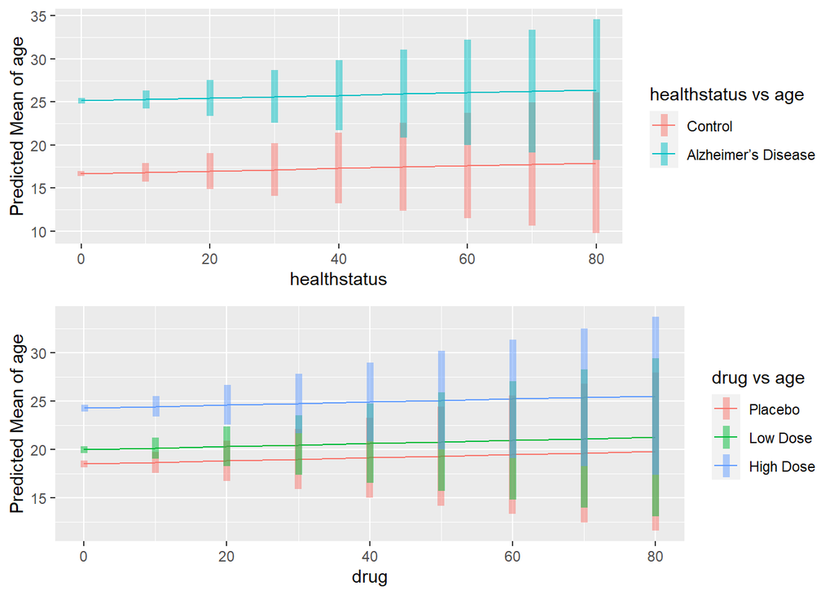

```r
library(emmeans)

library(ggplot2)
mylist_plot_educ <- list(treatment.age = seq(0,80,by=10), type = c("C","AD"))
educ_x_type_plot <- emmip(lm.3a3, treatment.healthstatus_F ~ treatment.age, at = mylist_plot_educ,
      CIs = TRUE,
      xlab = "healthstatus",
      ylab = "Predicted Mean of age",
      tlab = "healthstatus vs age") +
  scale_color_discrete(labels=c("Control","Alzheimer’s Disease"))


mylist_plot_inc <- list(treatment.age = seq(0,80,by=10), type = c("P","L", "H"))
inc_x_type_plot <- emmip(lm.3a3, treatment.drugtx_F ~ treatment.age, at = mylist_plot_inc,
      CIs = TRUE,
      xlab = "drug",
      ylab = "Predicted Mean of age",
      tlab = "drug vs age") +
  scale_color_discrete(labels=c("Placebo","Low Dose", "High Dose"))

grid.arrange(educ_x_type_plot, inc_x_type_plot, ncol=1)
```

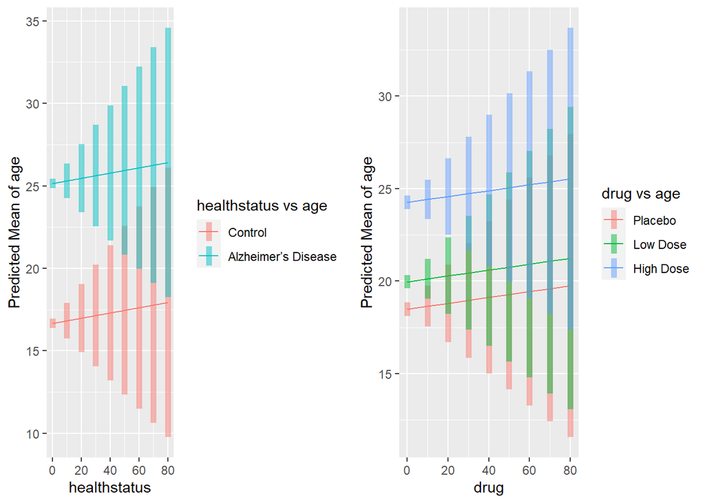

```r
grid.arrange(educ_x_type_plot, inc_x_type_plot, ncol=2)
```

8. Select one of the figures created above and, using the results from the statistical tests comparing the EM means above, report and briefly summarize the findings of the interaction effect in a sentence or two that includes mention of the differences in EM means (ie, `estimate` and `p.value`) among subgroups.  
   I have selected the second plot.

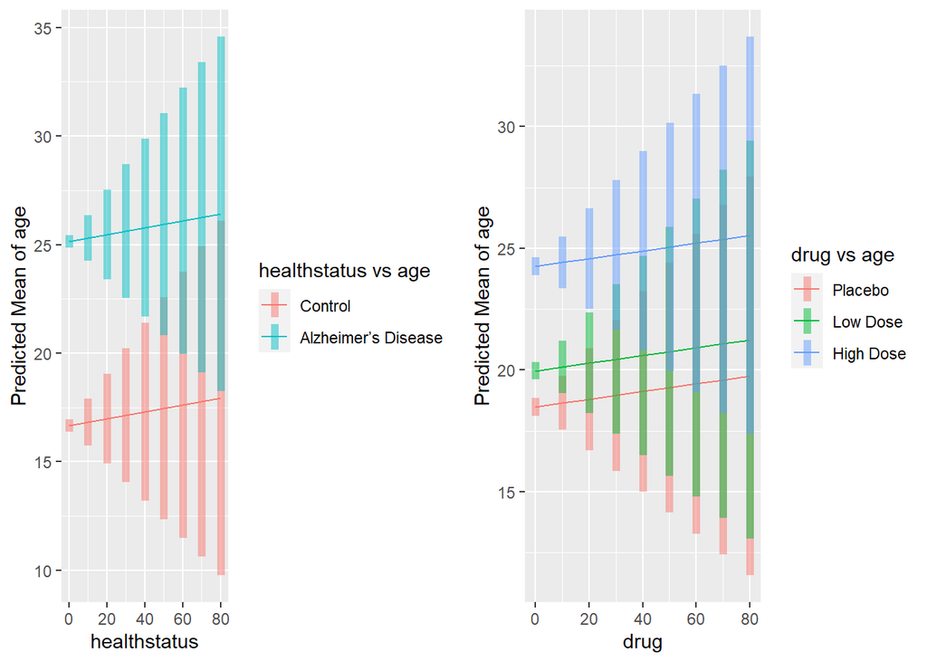

```r
grid.arrange(educ_x_type_plot, inc_x_type_plot, ncol=2)
```

From the results from the statistical tests comparing the EM means, it can be seen that the difference of in the comparison of different interaction is statistically significant (p<.0001). The interaction between high dose and placebo effect is much higher than other type of interactions.

### Part IV: Outliers, Leverage, & Influential Data

Employ the methods of outlier, leverage, and influential observation detection in the regression of `moral` integration of US cities on ethnic `hetero`geneity (centered), geographic `mobility` (centered), and `region` (dummy coded) using the `Angell` data set from the `carData` package (as in Part II above). Retain all predictors throughout this exercise regardless of statistical significance in this model.

```r
library(tidyverse)
library(car)
library(carData)
library(ggpubr)
library(jtools)
library(broom)
library(cowplot)
library(lmtest)
library(gtsummary)
library(apaTables)
library(ppcor)
library(readxl)
library(dplyr)
library(emmeans)

Angell <- Angell %>%
  drop_na()
Angell$hetero_c <- scale(Angell$hetero, scale = FALSE)
Angell$mobility_c<-scale(Angell$mobility, scale = FALSE)
table(Angell$region)
```

```
##
##  E MW  S  W
##  9 14 14  6
```

```r
Angell$region_F <- factor(Angell$region, labels=c('E','MW','S', 'W'))
Angell$region_F
```

```
##  [1] E  E  E  E  MW E  E  MW E  MW MW W  MW MW E  MW MW W  E  MW MW MW W  MW W
## [26] W  MW MW W  S  S  S  S  S  S  S  S  S  S  S  S  S  S
## Levels: E MW S W
```

```r
contrasts(Angell$region_F)
```

```
##    MW S W
## E   0 0 0
## MW  1 0 0
## S   0 1 0
## W   0 0 1
```

```r
dim(Angell)
```

```
## [1] 43  7
```

```r
head(Angell)
```

|  | moral | hetero | mobility | region | hetero_c | mobility_c | region_F |
| --- | --- | --- | --- | --- | --- | --- | --- |
| Rochester | 19.0 | 20.6 | 15.0 | E | -10.772093 | -12.597674 | E |
| Syracuse | 17.0 | 15.6 | 20.2 | E | -15.772093 | -7.397674 | E |
| Worcester | 16.4 | 22.1 | 13.6 | E | -9.272093 | -13.997674 | E |
| Erie | 16.2 | 14.0 | 14.8 | E | -17.372093 | -12.797674 | E |
| Milwaukee | 15.8 | 17.4 | 17.6 | MW | -13.972093 | -9.997674 | MW |
| Bridgeport | 15.3 | 27.9 | 17.5 | E | -3.472093 | -10.097674 | E |

|  | moral <dbl> | hetero <dbl> | mobility <dbl> | region <fct> | hetero_c <dbl[,1]> | mobility_c <dbl[,1]> | region_F <fct> |
| --- | --- | --- | --- | --- | --- | --- | --- |
| Rochester | 19.0 | 20.6 | 15.0 | E | -10.772093 | -12.597674 | E |
| Syracuse | 17.0 | 15.6 | 20.2 | E | -15.772093 | -7.397674 | E |
| Worcester | 16.4 | 22.1 | 13.6 | E | -9.272093 | -13.997674 | E |
| Erie | 16.2 | 14.0 | 14.8 | E | -17.372093 | -12.797674 | E |
| Milwaukee | 15.8 | 17.4 | 17.6 | MW | -13.972093 | -9.997674 | MW |
| Bridgeport | 15.3 | 27.9 | 17.5 | E | -3.472093 | -10.097674 | E |

6 rows

```r
lm.4a1 <- lm(moral ~ hetero_c + mobility_c + region_F, data=Angell)
summ(lm.4a1)
```

```
## MODEL INFO:
## Observations: 43
## Dependent Variable: moral
## Type: OLS linear regression
##
## MODEL FIT:
## F(5,37) = 16.27, p = 0.00
## R² = 0.69
## Adj. R² = 0.65
##
## Standard errors: OLS
## ------------------------------------------------
##                      Est.   S.E.   t val.      p
## ----------------- ------- ------ -------- ------
## (Intercept)         14.06   1.10    12.81   0.00
## hetero_c            -0.07   0.03    -2.34   0.02
## mobility_c          -0.07   0.06    -1.14   0.26
## region_FMW          -2.52   1.08    -2.35   0.02
## region_FS           -4.59   1.83    -2.51   0.02
## region_FW           -3.86   1.63    -2.38   0.02
## ------------------------------------------------
```

1. Present results of the initial regression model using the `tbl_regression()` command from the `gtsummary` package. Use code from the prior section of this homework assignment to format this table and make it look better (eg, add intercept, format variable names, add model fit statistics to the bottom).

```r
library(gtsummary)
tbl_regression(lm.4a1,
               intercept = TRUE,
               label = list(hetero_c ~ "`heterogeneity (centered)",
                            mobility_c ~ "mobility (centered)",
                            region_F ~ "region"),
               pvalue_fun = function(x) style_pvalue(x, digits = 3),
               estimate_fun = function(x) style_sigfig(x, digits = 2)) %>%
  add_glance_table(include = c(nobs, adj.r.squared, statistic, df, df.residual , p.value),
                   label = list(nobs ~ "N", statistic ~ "F-statistic", df ~ "df_reg",
                                df.residual ~ "df_res", p.value = "p-value"))
```

| **Characteristic** | **Beta** | **95% CI**<sup>1</sup> | **p-value** |
| --- | --- | --- | --- |
| (Intercept) | 14 | 12, 16 | <0.001 |
| `heterogeneity (centered) | -0.07 | -0.12, -0.01 | 0.025 |
| mobility (centered) | -0.07 | -0.19, 0.05 | 0.263 |
| region |  |  |  |
| E | — | — |  |
| MW | -2.5 | -4.7, -0.35 | 0.024 |
| S | -4.6 | -8.3, -0.88 | 0.017 |
| W | -3.9 | -7.2, -0.57 | 0.023 |
| N | 43 |  |  |
| Adjusted R² | 0.645 |  |  |
| F-statistic | 16.3 |  |  |
| df_reg | 5 |  |  |
| df_res | 37 |  |  |
| p-value | <0.001 |  |  |

<sup>1</sup> CI = Confidence Interval

2. Conduct an analysis of outliers, leverage or hat values, and influential data points using the methods discussed in class. Identify one or more influential values to remove from the data set and re-run the analysis without them included. If necessary, repeat this process up to 2 more times (checking for influential values and re-running the analysis without them included each time). Write a brief summary of what was done (which cases were dropped at each step and your reason(s) for doing so).

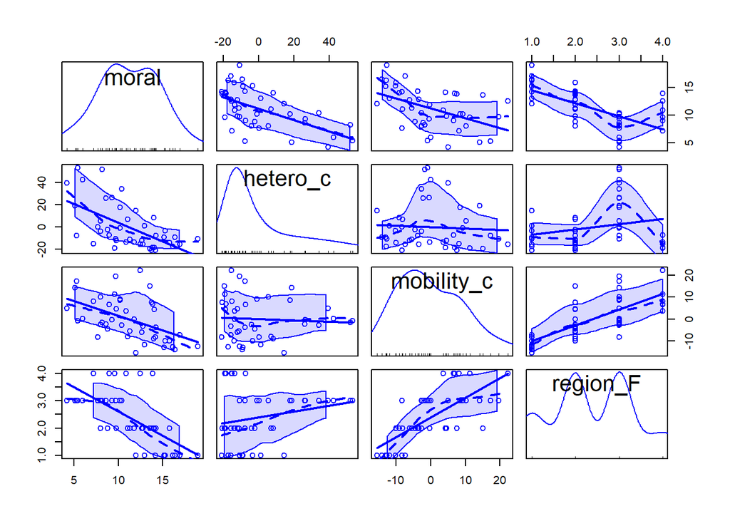

```r
scatterplotMatrix(~ moral + hetero_c + mobility_c + region_F, data=Angell)
```

```r
Angell1 <- augment(lm.4a1, Angell)
names(Angell1)
```

```
##  [1] ".rownames"  "moral"      "hetero"     "mobility"   "region"
##  [6] "hetero_c"   "mobility_c" "region_F"   ".fitted"    ".resid"
## [11] ".hat"       ".sigma"     ".cooksd"    ".std.resid"
```

```r
ksize.Angell1 <- sum(hatvalues(lm.4a1)) - 1
ksize.Angell1
```

```
## [1] 5
```

```r
nsize.Angell1 <- length(Angell1$mobility_c)
nsize.Angell1
```

```
## [1] 43
```

```r
resid(lm.4a1)
```

```
##       Rochester        Syracuse       Worcester            Erie       Milwaukee
##    3.3807460449    1.3982956571    0.7862474382    0.1285804048    2.6679535328
##      Bridgeport         Buffalo          Dayton         Reading      Des_Moines
##    0.3342065309   -0.3264402321    2.0039132959   -1.7878901170    1.6177764110
##       Cleveland          Denver          Peoria         Wichita         Trenton
##    2.4175433401    2.9522229469    1.4001601946    1.7913234041   -1.7744191237
##    Grand_Rapids          Toledo       San_Diego       Baltimore      South_Bend
##   -0.0009380346   -0.0432419628    2.7745137279   -2.1393266031   -0.6393765639
##           Akron         Detroit          Tacoma           Flint         Spokane
##   -1.3298322939   -0.5149555809    0.0492286981   -2.2233290258   -1.0982340510
##         Seattle    Indianapolis        Columbus Portland_Oregon        Richmond
##   -1.2434312538   -3.1775993377   -3.9693973788   -3.4343000680    3.0075482030
##         Houston      Fort_Worth   Oklahoma_City     Chattanooga       Nashville
##    2.4777122817    1.2951035031    0.8434969031    1.5571347627    0.7160728834
##      Birmingham          Dallas      Louisville    Jacksonville         Memphis
##    2.0580190600   -0.4188407353   -2.3092582395   -0.6456865760   -0.5950903262
##           Tulsa           Miami         Atlanta
##   -3.5052086070   -2.1589740478   -2.3220290652
```

```r
mean(resid(lm.4a1)); sd(resid(lm.4a1))
```

```
## [1] -1.743801e-16
```

```
## [1] 1.996975
```

```r
scale(resid(lm.4a1))
```

```
##                          [,1]
## Rochester        1.6929335797
## Syracuse         0.7002068895
## Worcester        0.3937192183
## Erie             0.0643875885
## Milwaukee        1.3359974588
## Bridgeport       0.1673563915
## Buffalo         -0.1634673599
## Dayton           1.0034744001
## Reading         -0.8952991960
## Des_Moines       0.8101134999
## Cleveland        1.2106027032
## Denver           1.4783474698
## Peoria           0.7011405704
## Wichita          0.8970184399
## Trenton         -0.8885534965
## Grand_Rapids    -0.0004697278
## Toledo          -0.0216537326
## San_Diego        1.3893582644
## Baltimore       -1.0712836150
## South_Bend      -0.3201725420
## Akron           -0.6659233541
## Detroit         -0.2578678148
## Tacoma           0.0246516346
## Flint           -1.1133484493
## Spokane         -0.5499488215
## Seattle         -0.6226573944
## Indianapolis    -1.5912063639
## Columbus        -1.9877050877
## Portland_Oregon -1.7197511528
## Richmond         1.5060520009
## Houston          1.2407327456
## Fort_Worth       0.6485326553
## Oklahoma_City    0.4223873111
## Chattanooga      0.7797467461
## Nashville        0.3585787911
## Birmingham       1.0305682615
## Dallas          -0.2097375952
## Louisville      -1.1563781384
## Jacksonville    -0.3233323272
## Memphis         -0.2979958810
## Tulsa           -1.7552591279
## Miami           -1.0811222182
## Atlanta         -1.1627732238
## attr(,"scaled:center")
## [1] -1.742792e-16
## attr(,"scaled:scale")
## [1] 1.996975
```

```r
mean(scale(resid(lm.4a1))); sd(scale(resid(lm.4a1)))
```

```
## [1] -3.326231e-17
```

```
## [1] 1
```

```r
rstandard(lm.4a1)
```

```
##       Rochester        Syracuse       Worcester            Erie       Milwaukee
##    1.6883793559    0.7016378363    0.3932315887    0.0648792955    1.3560617166
##      Bridgeport         Buffalo          Dayton         Reading      Des_Moines
##    0.1673943866   -0.1629148865    0.9788870876   -0.9018077796    0.7974154181
##       Cleveland          Denver          Peoria         Wichita         Trenton
##    1.2094343317    1.5319717139    0.6997839134    0.9635488815   -0.8916757284
##    Grand_Rapids          Toledo       San_Diego       Baltimore      South_Bend
##   -0.0004609077   -0.0213339386    1.5396083344   -1.1078388030   -0.3121682200
##           Akron         Detroit          Tacoma           Flint         Spokane
##   -0.6537468664   -0.2564572752    0.0257653854   -1.0988814935   -0.5662424682
##         Seattle    Indianapolis        Columbus Portland_Oregon        Richmond
##   -0.6432675940   -1.5563742788   -1.9404804487   -1.7704217124    1.4944276664
##         Houston      Fort_Worth   Oklahoma_City     Chattanooga       Nashville
##    1.2132463960    0.6537393332    0.4511979502    0.7657166111    0.3547897734
##      Birmingham          Dallas      Louisville    Jacksonville         Memphis
##    1.0743941851   -0.2078594908   -1.3943564792   -0.3249481944   -0.3135244269
##           Tulsa           Miami         Atlanta
##   -1.8325983448   -1.0886977190   -1.1706885961
```

```r
mean(rstandard(lm.4a1)); sd(rstandard(lm.4a1))
```

```
## [1] -0.002121732
```

```
## [1] 1.018719
```

```r
Angell1$.std.resid
```

```
##  [1]  1.6883793559  0.7016378363  0.3932315887  0.0648792955  1.3560617166
##  [6]  0.1673943866 -0.1629148865  0.9788870876 -0.9018077796  0.7974154181
## [11]  1.2094343317  1.5319717139  0.6997839134  0.9635488815 -0.8916757284
## [16] -0.0004609077 -0.0213339386  1.5396083344 -1.1078388030 -0.3121682200
## [21] -0.6537468664 -0.2564572752  0.0257653854 -1.0988814935 -0.5662424682
## [26] -0.6432675940 -1.5563742788 -1.9404804487 -1.7704217124  1.4944276664
## [31]  1.2132463960  0.6537393332  0.4511979502  0.7657166111  0.3547897734
## [36]  1.0743941851 -0.2078594908 -1.3943564792 -0.3249481944 -0.3135244269
## [41] -1.8325983448 -1.0886977190 -1.1706885961
```

```r
rstudent(lm.4a1)
```

```
##       Rochester        Syracuse       Worcester            Erie       Milwaukee
##    1.7335241766    0.6967419965    0.3886943194    0.0640001835    1.3721433969
##      Bridgeport         Buffalo          Dayton         Reading      Des_Moines
##    0.1651793646   -0.1607559221    0.9783195541   -0.8994778673    0.7934129527
##       Cleveland          Denver          Peoria         Wichita         Trenton
##    1.2172828982    1.5614611564    0.6948762842    0.9625924655   -0.8891487722
##    Grand_Rapids          Toledo       San_Diego       Baltimore      South_Bend
##   -0.0004546366   -0.0210437968    1.5697761537   -1.1113529436   -0.3083271324
##           Akron         Detroit          Tacoma           Flint         Spokane
##   -0.6486088397   -0.2531930330    0.0254150476   -1.1020627894   -0.5609740323
##         Seattle    Indianapolis        Columbus Portland_Oregon        Richmond
##   -0.6380933688   -1.5880612542   -2.0196016381   -1.8253600683    1.5207033482
##         Houston      Fort_Worth   Oklahoma_City     Chattanooga       Nashville
##    1.2212784037    0.6486012783    0.4462883831    0.7613547206    0.3505592946
##      Birmingham          Dallas      Louisville    Jacksonville         Memphis
##    1.0767044430   -0.2051511531   -1.4130102557   -0.3209852688   -0.3096702122
##           Tulsa           Miami         Atlanta
##   -1.8957467789   -1.0915098985   -1.1767598606
```

```r
mean(rstudent(lm.4a1)); sd(rstudent(lm.4a1))
```

```
## [1] -0.00442883
```

```
## [1] 1.034398
```

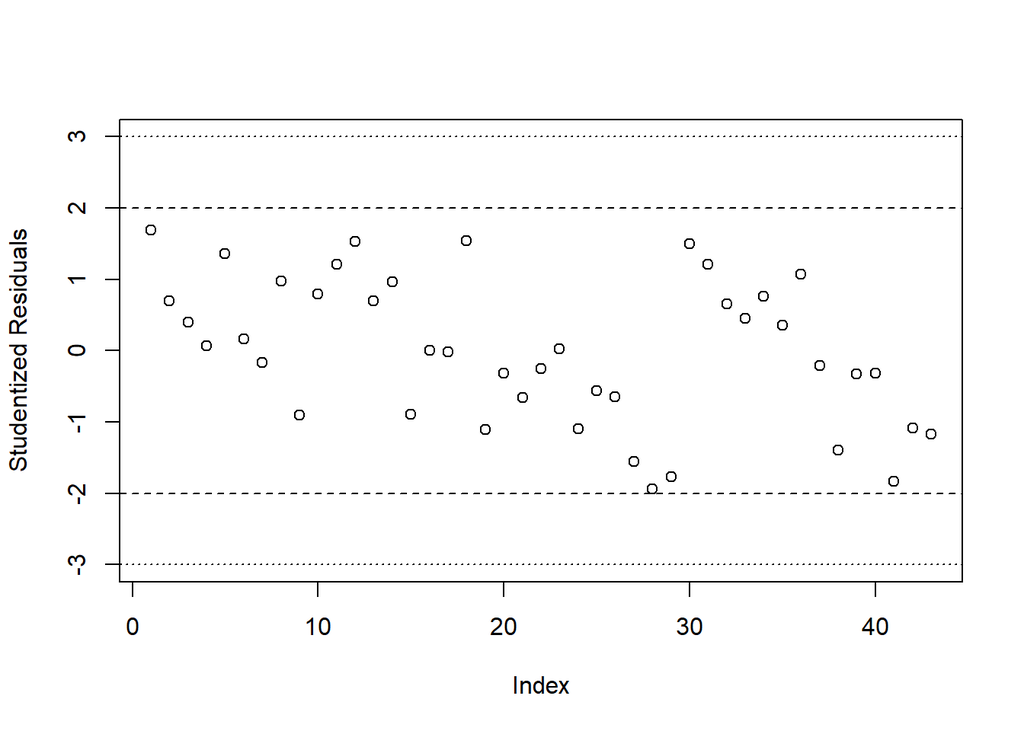

```
## integer(0)
```

```r
plot(Angell1$.std.resid, ylim = c(-3,3), ylab = "Studentized Residuals")
abline(h=c(-3,-2,3,2), lty = c(3,2))
identify(Angell1$.std.resid, labels=Angell1$.rownames)
```

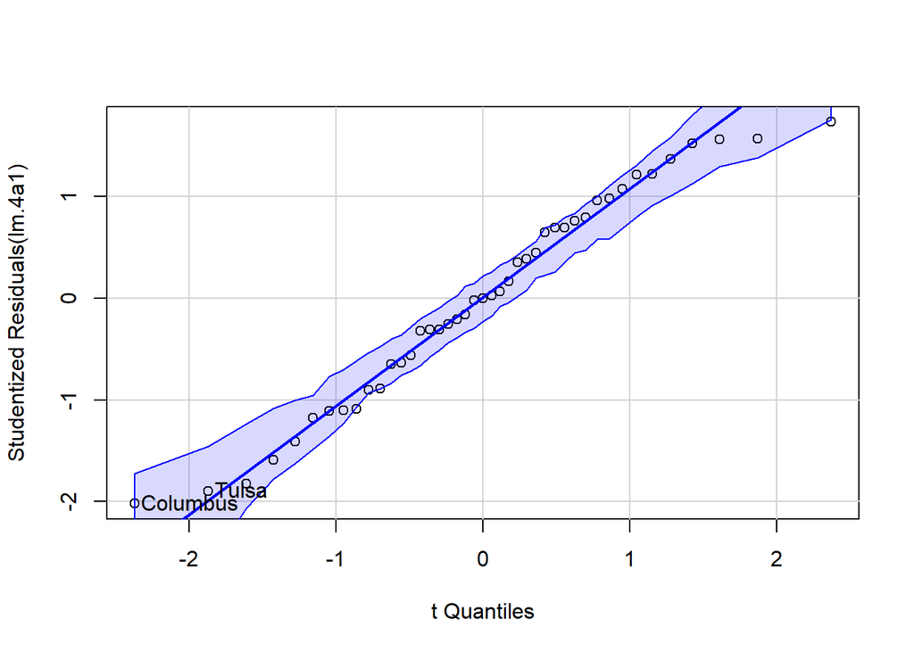

```
## Columbus    Tulsa
##       28       41
```

```r
qqPlot(lm.4a1, distribution = "t", simulate = T, envelope = .95, labels = row.names(Angell1))
```

```r
outlierTest(lm.4a1)
```

```
## No Studentized residuals with Bonferroni p < 0.05
## Largest |rstudent|:
##           rstudent unadjusted p-value Bonferroni p
## Columbus -2.019602           0.050917           NA
```

```r
hatvalues(lm.4a1)
```

```
##       Rochester        Syracuse       Worcester            Erie       Milwaukee
##      0.11428866      0.12263725      0.11686140      0.13235014      0.14492386
##      Bridgeport         Buffalo          Dayton         Reading      Des_Moines
##      0.11944749      0.11306255      0.07423698      0.13171786      0.09076757
##       Cleveland          Denver          Peoria         Wichita         Trenton
##      0.11734471      0.17964093      0.11562854      0.23650241      0.12520619
##    Grand_Rapids          Toledo       San_Diego       Baltimore      South_Bend
##      0.08500870      0.09243886      0.28260157      0.17622575      0.07329133
##           Akron         Detroit          Tacoma           Flint         Spokane
##      0.08592531      0.10933032      0.19356273      0.09569916      0.16901706
##         Seattle    Indianapolis        Columbus Portland_Oregon        Richmond
##      0.17459445      0.07917446      0.07564714      0.16875280      0.10528943
##         Houston      Fort_Worth   Oklahoma_City     Chattanooga       Nashville
##      0.07867914      0.13302435      0.22795978      0.08646869      0.10013068
##      Birmingham          Dallas      Louisville    Jacksonville         Memphis
##      0.18945214      0.10305609      0.39409499      0.12778724      0.20415189
##           Tulsa           Miami         Atlanta
##      0.19183445      0.13126485      0.13092011
```

```r
Angell1$.hat
```

```
##  [1] 0.11428866 0.12263725 0.11686140 0.13235014 0.14492386 0.11944749
##  [7] 0.11306255 0.07423698 0.13171786 0.09076757 0.11734471 0.17964093
## [13] 0.11562854 0.23650241 0.12520619 0.08500870 0.09243886 0.28260157
## [19] 0.17622575 0.07329133 0.08592531 0.10933032 0.19356273 0.09569916
## [25] 0.16901706 0.17459445 0.07917446 0.07564714 0.16875280 0.10528943
## [31] 0.07867914 0.13302435 0.22795978 0.08646869 0.10013068 0.18945214
## [37] 0.10305609 0.39409499 0.12778724 0.20415189 0.19183445 0.13126485
## [43] 0.13092011
```

```r
sum(Angell1$.hat)
```

```
## [1] 6
```

```r
dfbeta(lm.4a1)
```

```
##                   (Intercept)      hetero_c    mobility_c    region_FMW
## Rochester        3.455565e-01 -2.666055e-03 -4.918568e-03 -3.789771e-01
## Syracuse         2.025229e-01 -8.360519e-04  2.738197e-03 -2.064090e-01
## Worcester        7.236010e-02 -6.391364e-04 -1.839880e-03 -8.138997e-02
## Erie             9.385853e-03 -2.837021e-04 -4.140698e-04 -1.277381e-02
## Milwaukee       -3.324640e-01 -7.776148e-03 -2.318093e-02  4.442416e-01
## Bridgeport       5.501298e-02  4.223201e-04  8.131900e-04 -4.966647e-02
## Buffalo         -3.451707e-02  1.682764e-04  4.318109e-04  3.681348e-02
## Dayton          -3.555810e-02 -2.207650e-04 -2.890982e-03  1.835793e-01
## Reading         -2.049749e-01  3.250171e-03 -1.544305e-04  2.362426e-01
## Des_Moines       5.035316e-02 -7.168244e-04  4.787621e-03  7.716499e-02
## Cleveland       -3.067980e-02  4.608158e-03 -5.728219e-03  2.621634e-01
## Denver          -1.599505e-01 -4.409902e-03 -1.070182e-02  1.007166e-01
## Peoria           8.688169e-02 -1.648769e-04  7.538374e-03  3.622077e-02
## Wichita          3.298492e-01  3.905579e-03  2.556583e-02 -8.501919e-02
## Trenton         -2.926131e-01 -3.212538e-03 -3.582918e-03  2.559527e-01
## Grand_Rapids     4.360341e-05  1.480759e-06  2.729627e-06 -9.827201e-05
## Toledo           2.716138e-03  6.447967e-05  1.887410e-04 -5.203651e-03
## San_Diego        5.025516e-01  9.365500e-03  3.665015e-02 -3.553062e-01
## Baltimore       -4.031821e-01 -8.296031e-03 -4.208463e-03  3.162810e-01
## South_Bend       5.524829e-06  2.745430e-04 -1.845455e-04 -4.691021e-02
## Akron            6.853833e-02  1.509177e-03  4.842089e-03 -1.503668e-01
## Detroit          3.993230e-03 -9.351132e-04  9.715536e-04 -5.285868e-02
## Tacoma          -3.751769e-03 -6.386051e-05 -2.776914e-04  2.704944e-03
## Flint           -1.390691e-01 -2.049293e-03 -1.050757e-02 -7.259850e-02
## Spokane          1.586316e-04  5.943201e-04 -3.869585e-04  5.006301e-03
## Seattle          9.433747e-03 -9.848096e-04  1.470139e-03 -1.671523e-02
## Indianapolis     1.041457e-02 -2.532702e-03  2.597130e-03 -2.774513e-01
## Columbus        -4.481529e-02 -3.445155e-03 -1.509396e-03 -2.976374e-01
## Portland_Oregon  7.294133e-02  1.462974e-03  5.249625e-03 -5.067274e-02
## Richmond        -1.077052e-01  2.470568e-03 -1.087235e-02  1.149045e-01
## Houston          6.901881e-02  3.357613e-04  5.673943e-03 -5.702322e-02
## Fort_Worth      -5.543075e-02 -4.519512e-03 -1.692859e-03  9.012855e-03
## Oklahoma_City    4.013694e-02 -2.886633e-03  5.376526e-03 -5.983587e-02
## Chattanooga     -6.193993e-02 -2.513028e-04 -5.125708e-03  5.160761e-02
## Nashville       -4.511813e-02 -4.529138e-04 -3.551793e-03  3.525615e-02
## Birmingham       1.173678e-01  1.043176e-02  3.003346e-03 -1.162063e-02
## Dallas           1.170624e-03  7.934946e-04 -4.346724e-04  5.851507e-03
## Louisville       8.350951e-01  2.442212e-02  5.493148e-02 -5.137351e-01
## Jacksonville    -2.202625e-02 -2.075293e-03 -4.843948e-04  1.163128e-03
```

[output cut: 33 more lines]

```
## Portland_Oregon -1.293404e-01 -7.912993e-01
## Richmond         3.484818e-01  2.508985e-01
## Houston          8.841288e-02 -1.196600e-01
## Fort_Worth       2.657817e-01  5.036069e-03
## Oklahoma_City    7.272297e-02 -1.356253e-01
## Chattanooga      2.139057e-01  1.084590e-01
## Nashville        1.287800e-01  7.322083e-02
## Birmingham      -1.708541e-01  7.812848e-03
## Dallas          -4.916648e-02  1.485143e-02
## Louisville      -1.889905e+00 -1.011564e+00
## Jacksonville     1.531955e-02 -3.985738e-03
## Memphis          7.049185e-02  1.012900e-02
## Tulsa           -3.609230e-01  4.289023e-01
## Miami            2.096081e-01  3.359237e-01
## Atlanta          2.301368e-01  1.589530e-01
```

```r
dfbetas(lm.4a1)
```

```
##                   (Intercept)      hetero_c    mobility_c    region_FMW
## Rochester        3.233535e-01 -9.642403e-02 -8.526325e-02 -3.617757e-01
## Syracuse         1.832871e-01 -2.924479e-02  4.590785e-02 -1.905698e-01
## Worcester        6.518649e-02 -2.225408e-02 -3.070524e-02 -7.479924e-02
## Erie             8.438155e-03 -9.858116e-03 -6.896233e-03 -1.171553e-02
## Milwaukee       -3.065938e-01 -2.771666e-01 -3.960174e-01  4.179321e-01
## Bridgeport       4.947420e-02  1.467956e-02  1.354784e-02 -4.556640e-02
## Buffalo         -3.104122e-02  5.849057e-03  7.193879e-03  3.377377e-02
## Dayton          -3.238810e-02 -7.772034e-03 -4.878169e-02  1.705840e-01
## Reading         -1.863271e-01  1.141929e-01 -2.600595e-03  2.190793e-01
## Des_Moines       4.566044e-02 -2.512371e-02  8.042623e-02  7.138409e-02
## Cleveland       -2.814235e-02  1.633777e-01 -9.734018e-02  2.453284e-01
## Denver          -1.485815e-01 -1.583309e-01 -1.841625e-01  9.544383e-02
## Peoria           7.862678e-02 -5.767129e-03  1.263818e-01  3.344011e-02
## Wichita          3.003190e-01  1.374392e-01  4.312130e-01 -7.896818e-02
## Trenton         -2.659254e-01 -1.128423e-01 -6.032087e-02  2.372978e-01
## Grand_Rapids     3.919851e-05  5.145068e-05  4.545869e-05 -9.012529e-05
## Toledo           2.441763e-03  2.240434e-03  3.143277e-03 -4.772299e-03
## San_Diego        4.669892e-01  3.363681e-01  6.309086e-01 -3.368192e-01
## Baltimore       -3.686170e-01 -2.931583e-01 -7.127910e-02  2.949953e-01
## South_Bend       4.973253e-06  9.551898e-03 -3.077442e-03 -4.307814e-02
## Akron            6.197342e-02  5.274360e-02  8.110905e-02 -1.387049e-01
## Detroit          3.593021e-03 -3.252050e-02  1.619447e-02 -4.851986e-02
## Tacoma          -3.372788e-03 -2.218927e-03 -4.624663e-03  2.480727e-03
## Flint           -1.271115e-01 -7.239621e-02 -1.779184e-01 -6.769391e-02
## Spokane          1.432283e-04  2.074040e-02 -6.472440e-03  4.611304e-03
## Seattle          8.528555e-03 -3.441131e-02  2.462148e-02 -1.541599e-02
## Indianapolis     9.684858e-03 -9.103191e-02  4.474146e-02 -2.632124e-01
## Columbus        -4.250904e-02 -1.263053e-01 -2.652302e-02 -2.880119e-01
## Portland_Oregon  6.854001e-02  5.313306e-02  9.138257e-02 -4.857499e-02
## Richmond        -9.988608e-02  8.855695e-02 -1.867911e-01  1.087109e-01
## Houston          6.331868e-02  1.190564e-02  9.643039e-02 -5.336836e-02
## Fort_Worth      -5.012133e-02 -1.579505e-01 -2.835680e-02  8.313848e-03
## Oklahoma_City    3.618190e-02 -1.005765e-01  8.978701e-02 -5.502709e-02
## Chattanooga     -5.612914e-02 -8.801822e-03 -8.604708e-02  4.770888e-02
## Nashville       -4.062938e-02 -1.576385e-02 -5.925177e-02  3.238857e-02
## Birmingham       1.071965e-01  3.682533e-01  5.081613e-02 -1.082752e-02
## Dallas           1.052980e-03  2.758700e-02 -7.243183e-03  5.369555e-03
## Louisville       7.712695e-01  8.717888e-01  9.398446e-01 -4.840355e-01
## Jacksonville    -1.982943e-02 -7.221155e-02 -8.078555e-03  1.068231e-03
```

[output cut: 33 more lines]

```
## Portland_Oregon -7.280376e-02 -5.019813e-01
## Richmond         1.935965e-01  1.570879e-01
## Houston          4.858799e-02 -7.411217e-02
## Fort_Worth       1.439614e-01  3.074254e-03
## Oklahoma_City    3.927063e-02 -8.253997e-02
## Chattanooga      1.161152e-01  6.635282e-02
## Nashville        6.946831e-02  4.451435e-02
## Birmingham      -9.347730e-02  4.817450e-03
## Dallas          -2.649238e-02  9.018769e-03
## Louisville      -1.045585e+00 -6.307249e-01
## Jacksonville     8.261609e-03 -2.422449e-03
## Memphis          3.801148e-02  6.155588e-03
## Tulsa           -2.038334e-01  2.729898e-01
## Miami            1.147298e-01  2.072220e-01
## Atlanta          1.262933e-01  9.830828e-02
```

```r
Angell1$.dfbetas_intrcpt <- dfbetas(lm.4a1)[,1]
Angell1$.dfbetas_ddpi <- dfbetas(lm.4a1)[,2]
Angell1$.dfbetas_dpi <- dfbetas(lm.4a1)[,3]
Angell1$.dfbetas_pop15 <- dfbetas(lm.4a1)[,4]
names(Angell1)
```

```
##  [1] ".rownames"        "moral"            "hetero"           "mobility"
##  [5] "region"           "hetero_c"         "mobility_c"       "region_F"
##  [9] ".fitted"          ".resid"           ".hat"             ".sigma"
## [13] ".cooksd"          ".std.resid"       ".dfbetas_intrcpt" ".dfbetas_ddpi"
## [17] ".dfbetas_dpi"     ".dfbetas_pop15"
```

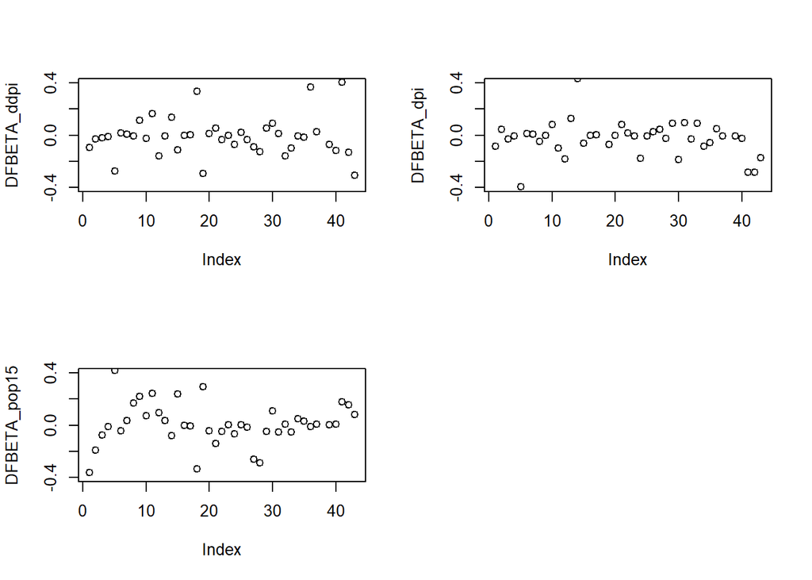

```r
dfbeta_threshold <- c(-1,1, -2*sqrt(nsize.Angell1), 2*sqrt(nsize.Angell1))
par(mfrow = c(2,2))

plot(Angell1$.dfbetas_ddpi, ylab = "DFBETA_ddpi", ylim = c(-.4,.4))
abline(h=dfbeta_threshold, lty=2)

plot(Angell1$.dfbetas_dpi, ylab = "DFBETA_dpi", ylim = c(-.4,.4))
abline(h=dfbeta_threshold, lty=2)

plot(Angell1$.dfbetas_pop15, ylab = "DFBETA_pop15", ylim = c(-.4,.4))
abline(h=dfbeta_threshold, lty=2)
par(mfrow = c(1,1))
```

```r
dffits(lm.4a1)
```

```
##       Rochester        Syracuse       Worcester            Erie       Milwaukee
##    0.6227093228    0.2604915232    0.1413934549    0.0249960376    0.5648941230
##      Bridgeport         Buffalo          Dayton         Reading      Des_Moines
##    0.0608368439   -0.0573957694    0.2770390341   -0.3503340758    0.2506843336
##       Cleveland          Denver          Peoria         Wichita         Trenton
##    0.4438413084    0.7306877685    0.2512595909    0.5357428757   -0.3363833360
##    Grand_Rapids          Toledo       San_Diego       Baltimore      South_Bend
##   -0.0001385758   -0.0067160427    0.9852462653   -0.5140230316   -0.0867094505
##           Akron         Detroit          Tacoma           Flint         Spokane
##   -0.1988623496   -0.0887081935    0.0124513516   -0.3585122060   -0.2529950207
##         Seattle    Indianapolis        Columbus Portland_Oregon        Richmond
##   -0.2934713772   -0.4656623400   -0.5777541506   -0.8224489195    0.5216696784
##         Houston      Fort_Worth   Oklahoma_City     Chattanooga       Nashville
##    0.3568938287    0.2540621232    0.2425072561    0.2342365998    0.1169379154
##      Birmingham          Dallas      Louisville    Jacksonville         Memphis
##    0.5205433887   -0.0695389546   -1.1395765469   -0.1228620159   -0.1568415175
##           Tulsa           Miami         Atlanta
##   -0.9236202782   -0.4242855180   -0.4567317143
```

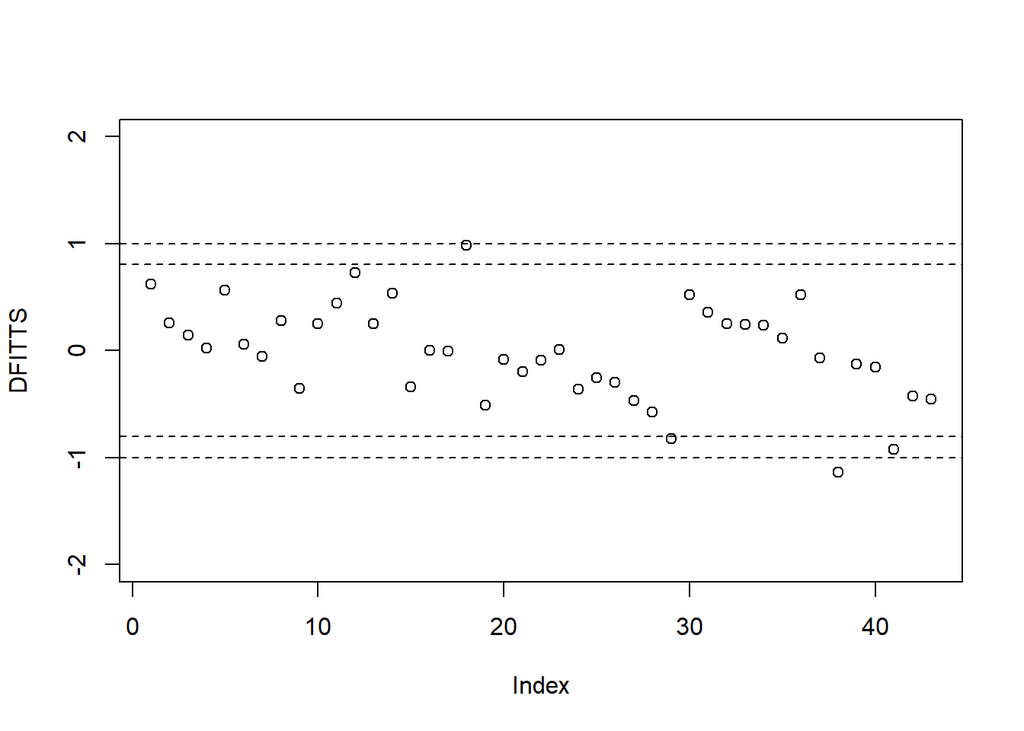

```
## integer(0)
```

```r
Angell1$.dffits <- dffits(lm.4a1)

plot(dffits(lm.4a1), ylim=c(-2,2), ylab = "DFITTS")
abline(h=c(-1,1,c(-2,2)*(sqrt((ksize.Angell1+1)/(nsize.Angell1-ksize.Angell1-1)))), lty=2)

identify(Angell1$mobility_c, dffits(lm.4a1), labels=Angell1$.rownames)
```

```r
cooks.distance(lm.4a1)
```

```
##       Rochester        Syracuse       Worcester            Erie       Milwaukee
##    6.130554e-02    1.146880e-02    3.410262e-03    1.070141e-04    5.194488e-02
##      Bridgeport         Buffalo          Dayton         Reading      Des_Moines
##    6.335083e-04    5.638922e-04    1.280662e-02    2.056177e-02    1.057971e-02
##       Cleveland          Denver          Peoria         Wichita         Trenton
##    3.241050e-02    8.565477e-02    1.067105e-02    4.793184e-02    1.896630e-02
##    Grand_Rapids          Toledo       San_Diego       Baltimore      South_Bend
##    3.289448e-09    7.726264e-06    1.556264e-01    4.375856e-02    1.284504e-03
##           Akron         Detroit          Tacoma           Flint         Spokane
##    6.695876e-03    1.345559e-03    2.655664e-05    2.129834e-02    1.086906e-02
##         Seattle    Indianapolis        Columbus Portland_Oregon        Richmond
##    1.458798e-02    3.471239e-02    5.135964e-02    1.060530e-01    4.380268e-02
##         Houston      Fort_Worth   Oklahoma_City     Chattanooga       Nashville
##    2.095055e-02    1.092905e-02    1.001847e-02    9.249544e-03    2.334418e-03
##      Birmingham          Dallas      Louisville    Jacksonville         Memphis
##    4.496731e-02    8.273645e-04    2.107622e-01    2.578351e-03    4.202568e-03
##           Tulsa           Miami         Atlanta
##    1.328647e-01    2.984863e-02    3.440948e-02
```

```r
lm.4a1$.cooksd
```

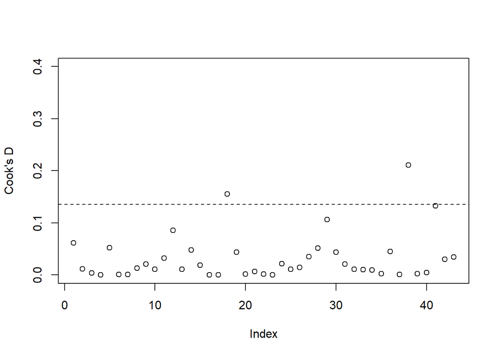

```
## integer(0)
```

```r
plot(Angell1$.cooksd, ylab = "Cook's D", ylim = c(0, .40))
cooks_threshold <- ksize.Angell1/(nsize.Angell1-ksize.Angell1-1)
abline(h=cooks_threshold, lty=2)
identify(Angell1$.cooksd, labels = Angell1$.rownames)
```

```r
influence.measures(lm.4a1)
```

```
## Influence measures of
##   lm(formula = moral ~ hetero_c + mobility_c + region_F, data = Angell) :
##
##                    dfb.1_  dfb.htr_  dfb.mbl_  dfb.r_FM  dfb.r_FS  dfb.r_FW
## Rochester        3.23e-01 -9.64e-02 -8.53e-02 -3.62e-01 -1.49e-01 -2.13e-01
## Syracuse         1.83e-01 -2.92e-02  4.59e-02 -1.91e-01 -1.07e-01 -1.48e-01
## Worcester        6.52e-02 -2.23e-02 -3.07e-02 -7.48e-02 -2.69e-02 -3.88e-02
## Erie             8.44e-03 -9.86e-03 -6.90e-03 -1.17e-02 -7.45e-04 -5.79e-03
## Milwaukee       -3.07e-01 -2.77e-01 -3.96e-01  4.18e-01  3.37e-01  2.77e-01
## Bridgeport       4.95e-02  1.47e-02  1.35e-02 -4.56e-02 -3.66e-02 -3.44e-02
## Buffalo         -3.10e-02  5.85e-03  7.19e-03  3.38e-02  1.56e-02  1.99e-02
## Dayton          -3.24e-02 -7.77e-03 -4.88e-02  1.71e-01  2.96e-02  3.73e-02
## Reading         -1.86e-01  1.14e-01 -2.60e-03  2.19e-01  7.47e-02  1.56e-01
## Des_Moines       4.57e-02 -2.51e-02  8.04e-02  7.14e-02 -3.18e-02 -6.61e-02
## Cleveland       -2.81e-02  1.63e-01 -9.73e-02  2.45e-01 -2.13e-02  9.61e-02
## Denver          -1.49e-01 -1.58e-01 -1.84e-01  9.54e-02  1.70e-01  5.01e-01
## Peoria           7.86e-02 -5.77e-03  1.26e-01  3.34e-02 -6.51e-02 -9.97e-02
## Wichita          3.00e-01  1.37e-01  4.31e-01 -7.90e-02 -2.93e-01 -3.21e-01
## Trenton         -2.66e-01 -1.13e-01 -6.03e-02  2.37e-01  2.06e-01  1.72e-01
## Grand_Rapids     3.92e-05  5.15e-05  4.55e-05 -9.01e-05 -4.75e-05 -2.94e-05
## Toledo           2.44e-03  2.24e-03  3.14e-03 -4.77e-03 -2.69e-03 -2.19e-03
## San_Diego        4.67e-01  3.36e-01  6.31e-01 -3.37e-01 -4.89e-01 -4.92e-02
## Baltimore       -3.69e-01 -2.93e-01 -7.13e-02  2.95e-01  3.28e-01  1.98e-01
## South_Bend       4.97e-06  9.55e-03 -3.08e-03 -4.31e-02 -2.65e-03  3.57e-03
## Akron            6.20e-02  5.27e-02  8.11e-02 -1.39e-01 -6.71e-02 -5.72e-02
## Detroit          3.59e-03 -3.25e-02  1.62e-02 -4.85e-02  5.94e-03 -1.66e-02
## Tacoma          -3.37e-03 -2.22e-03 -4.62e-03  2.48e-03  3.47e-03  9.53e-03
## Flint           -1.27e-01 -7.24e-02 -1.78e-01 -6.77e-02  1.28e-01  1.31e-01
## Spokane          1.43e-04  2.07e-02 -6.47e-03  4.61e-03 -5.86e-03 -1.27e-01
## Seattle          8.53e-03 -3.44e-02  2.46e-02 -1.54e-02  2.28e-03 -1.77e-01
## Indianapolis     9.68e-03 -9.10e-02  4.47e-02 -2.63e-01  1.70e-02 -4.61e-02
## Columbus        -4.25e-02 -1.26e-01 -2.65e-02 -2.88e-01  7.10e-02  5.47e-03
## Portland_Oregon  6.85e-02  5.31e-02  9.14e-02 -4.86e-02 -7.28e-02 -5.02e-01
## Richmond        -9.99e-02  8.86e-02 -1.87e-01  1.09e-01  1.94e-01  1.57e-01
## Houston          6.33e-02  1.19e-02  9.64e-02 -5.34e-02  4.86e-02 -7.41e-02
## Fort_Worth      -5.01e-02 -1.58e-01 -2.84e-02  8.31e-03  1.44e-01  3.07e-03
## Oklahoma_City    3.62e-02 -1.01e-01  8.98e-02 -5.50e-02  3.93e-02 -8.25e-02
## Chattanooga     -5.61e-02 -8.80e-03 -8.60e-02  4.77e-02  1.16e-01  6.64e-02
## Nashville       -4.06e-02 -1.58e-02 -5.93e-02  3.24e-02  6.95e-02  4.45e-02
## Birmingham       1.07e-01  3.68e-01  5.08e-02 -1.08e-02 -9.35e-02  4.82e-03
```

[output cut: 36 more lines]

```
## Portland_Oregon -0.822449 0.834 1.06e-01 0.1688
## Richmond         0.521670 0.907 4.38e-02 0.1053
## Houston          0.356894 1.003 2.10e-02 0.0787
## Fort_Worth       0.254062 1.268 1.09e-02 0.1330
## Oklahoma_City    0.242507 1.477 1.00e-02 0.2280
## Chattanooga      0.234237 1.172 9.25e-03 0.0865
## Nashville        0.116938 1.283 2.33e-03 0.1001
## Birmingham       0.520543 1.202 4.50e-02 0.1895
## Dallas          -0.069539 1.305 8.27e-04 0.1031
## Louisville      -1.139577 1.407 2.11e-01 0.3941   *
## Jacksonville    -0.122862 1.328 2.58e-03 0.1278
## Memphis         -0.156842 1.458 4.20e-03 0.2042
## Tulsa           -0.923620 0.824 1.33e-01 0.1918
## Miami           -0.424286 1.116 2.98e-02 0.1313
## Atlanta         -0.456732 1.081 3.44e-02 0.1309
```

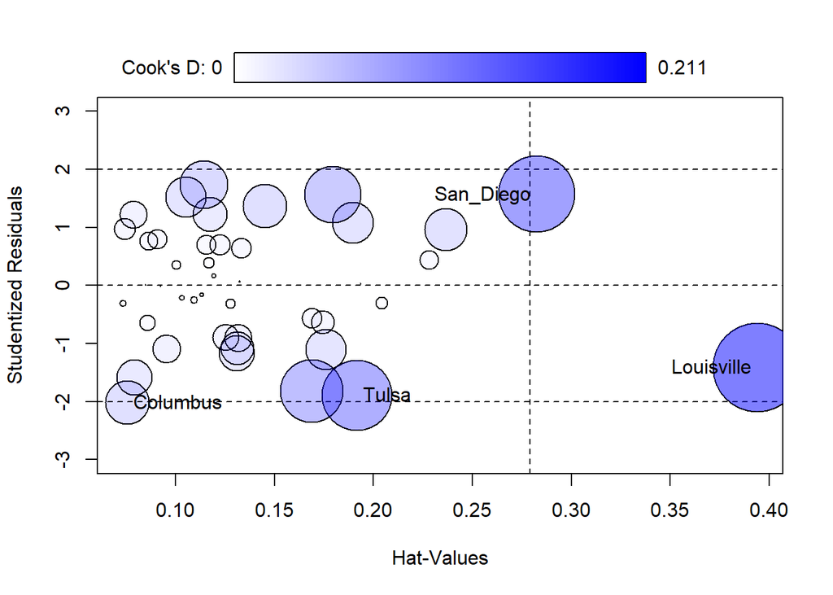

|  | StudRes | Hat | CookD |
| --- | --- | --- | --- |
| San_Diego | 1.569776 | 0.28260157 | 0.15562644 |
| Columbus | -2.019602 | 0.07564714 | 0.05135964 |
| Louisville | -1.413010 | 0.39409499 | 0.21076222 |
| Tulsa | -1.895747 | 0.19183445 | 0.13286469 |

|  | StudRes <dbl> | Hat <dbl> | CookD <dbl> |  |
| --- | --- | --- | --- | --- |
| San_Diego | 1.569776 | 0.28260157 | 0.15562644 |  |
| Columbus | -2.019602 | 0.07564714 | 0.05135964 |  |
| Louisville | -1.413010 | 0.39409499 | 0.21076222 |  |
| Tulsa | -1.895747 | 0.19183445 | 0.13286469 |  |

```r
influencePlot(lm.4a1, ylim = c(-3,3))
```

4 rows

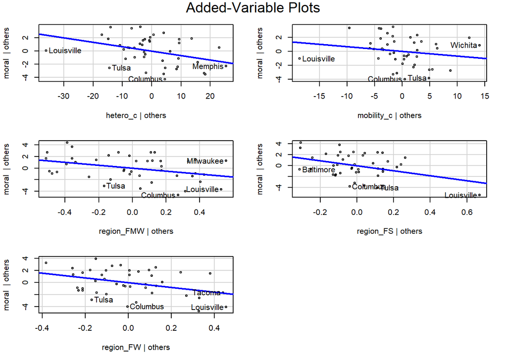

```r
avPlots(lm.4a1, ask=FALSE, identify.points=TRUE)
```

```r
Angell1[c('Columbus'),'mobility_c']
```

| mobility_c |
| --- |
| NA |

| mobility_c <dbl[,1]> |  |  |  |  |
| --- | --- | --- | --- | --- |
| NA |  |  |  |  |

1 row

```r
lm.4a2 <- lm(moral ~ hetero_c + mobility_c + region_F, data = Angell1, subset = -c(49))
summ(lm.4a2)
```

```
## MODEL INFO:
## Observations: 43
## Dependent Variable: moral
## Type: OLS linear regression
##
## MODEL FIT:
## F(5,37) = 16.27, p = 0.00
## R² = 0.69
## Adj. R² = 0.65
##
## Standard errors: OLS
## ------------------------------------------------
##                      Est.   S.E.   t val.      p
## ----------------- ------- ------ -------- ------
## (Intercept)         14.06   1.10    12.81   0.00
## hetero_c            -0.07   0.03    -2.34   0.02
## mobility_c          -0.07   0.06    -1.14   0.26
## region_FMW          -2.52   1.08    -2.35   0.02
## region_FS           -4.59   1.83    -2.51   0.02
## region_FW           -3.86   1.63    -2.38   0.02
## ------------------------------------------------
```

```r
Angell2 <- slice(Angell1, -28)
dim(Angell2)
```

```
## [1] 42 19
```

```r
lm.4a3 <- lm(moral ~ hetero_c + mobility_c + region_F, data = Angell2)
summ(lm.4a3)
```

```
## MODEL INFO:
## Observations: 42
## Dependent Variable: moral
## Type: OLS linear regression
##
## MODEL FIT:
## F(5,36) = 17.94, p = 0.00
## R² = 0.71
## Adj. R² = 0.67
##
## Standard errors: OLS
## ------------------------------------------------
##                      Est.   S.E.   t val.      p
## ----------------- ------- ------ -------- ------
## (Intercept)         14.10   1.05    13.37   0.00
## hetero_c            -0.06   0.03    -2.31   0.03
## mobility_c          -0.07   0.06    -1.16   0.26
## region_FMW          -2.23   1.04    -2.13   0.04
## region_FS           -4.71   1.76    -2.68   0.01
## region_FW           -3.87   1.56    -2.48   0.02
## ------------------------------------------------
```

```r
exclude_rows_2 <- c('Louisville')

Angell3 <- slice(Angell2, -41)
dim(Angell3)
```

```
## [1] 41 19
```

```r
lm.4a4 <- lm(moral ~ hetero_c + mobility_c + region_F, data = Angell3)
summ(lm.4a4)
```

```
## MODEL INFO:
## Observations: 41
## Dependent Variable: moral
## Type: OLS linear regression
##
## MODEL FIT:
## F(5,35) = 16.47, p = 0.00
## R² = 0.70
## Adj. R² = 0.66
##
## Standard errors: OLS
## ------------------------------------------------
##                      Est.   S.E.   t val.      p
## ----------------- ------- ------ -------- ------
## (Intercept)         14.33   1.07    13.41   0.00
## hetero_c            -0.06   0.03    -2.16   0.04
## mobility_c          -0.05   0.06    -0.83   0.41
## region_FMW          -2.39   1.05    -2.28   0.03
## region_FS           -4.92   1.76    -2.79   0.01
## region_FW           -4.21   1.58    -2.66   0.01
## ------------------------------------------------
```

3. Present results of the final regression model in a formatted table as was done before using the `tbl_regression()` command. Briefly discuss how the initial and final models differ from one another in terms of individuals slopes as well as overall fit.

```r
tbl_regression(lm.4a3,
               intercept = TRUE,
               label = list(hetero_c ~ "`heterogeneity (centered)",
                            mobility_c ~ "mobility (centered)",
                            region_F ~ "region"),
               pvalue_fun = function(x) style_pvalue(x, digits = 3),
               estimate_fun = function(x) style_sigfig(x, digits = 2)) %>%
  add_glance_table(include = c(nobs, adj.r.squared, statistic, df, df.residual , p.value),
                   label = list(nobs ~ "N", statistic ~ "F-statistic", df ~ "df_reg",
                                df.residual ~ "df_res", p.value = "p-value"))
```

| **Characteristic** | **Beta** | **95% CI**<sup>1</sup> | **p-value** |
| --- | --- | --- | --- |
| (Intercept) | 14 | 12, 16 | <0.001 |
| `heterogeneity (centered) | -0.06 | -0.12, -0.01 | 0.027 |
| mobility (centered) | -0.07 | -0.18, 0.05 | 0.255 |
| region |  |  |  |
| E | — | — |  |
| MW | -2.2 | -4.3, -0.11 | 0.040 |
| S | -4.7 | -8.3, -1.1 | 0.011 |
| W | -3.9 | -7.0, -0.71 | 0.018 |
| N | 42 |  |  |
| Adjusted R² | 0.674 |  |  |
| F-statistic | 17.9 |  |  |
| df_reg | 5 |  |  |
| df_res | 36 |  |  |
| p-value | <0.001 |  |  |

<sup>1</sup> CI = Confidence Interval

```r
summary(lm.4a1)$adj.r.squared
```

```
## [1] 0.6451677
```

```r
summary(lm.4a3)$adj.r.squared
```

```
## [1] 0.6738432
```

```r
coef(lm.4a1)
```

```
## (Intercept)    hetero_c  mobility_c  region_FMW   region_FS   region_FW
## 14.05553565 -0.06647088 -0.06728923 -2.52496230 -4.58939053 -3.86451557
```

```r
coef(lm.4a3)
```

```
## (Intercept)    hetero_c  mobility_c  region_FMW   region_FS   region_FW
## 14.10035094 -0.06302572 -0.06577983 -2.22732486 -4.71428039 -3.87306204
```

From the above analysis, we can see that the overall fit of the model improved from 0.65 to 0.67.Heterogeneity and regions values got changed from first model to the final model.

### Part V: Robust Regression

Also using the `Angell` data set from the `carData` package (used in Parts II and IV), use the Huber robust regression modeling technique (from the MASS package) to regress `moral` integration of US cities on ethnic `hetero`geneity (centered), geographic `mobility` (centered), and `region` (not centered, but dummy coded).

```r
library(faraway)
library(MASS)
library(car)
library(quantreg)
library(MASS)
library(jtools)
library(ggstance)
library(gtsummary)
library(broom)
library(broom.mixed)
```

```r
library(tidyverse)
library(sjPlot)
library(stargazer)
library(L1pack)
Angell <- Angell %>%
  drop_na()
Angell$hetero_c <- scale(Angell$hetero, scale = FALSE)
Angell$mobility_c<-scale(Angell$mobility, scale = FALSE)
table(Angell$region)
```

```
##
##  E MW  S  W
##  9 14 14  6
```

```r
Angell$region_F <- factor(Angell$region, labels=c('E','MW','S', 'W'))
Angell$region_F
```

```
##  [1] E  E  E  E  MW E  E  MW E  MW MW W  MW MW E  MW MW W  E  MW MW MW W  MW W
## [26] W  MW MW W  S  S  S  S  S  S  S  S  S  S  S  S  S  S
## Levels: E MW S W
```

```r
contrasts(Angell$region_F)
```

```
##    MW S W
## E   0 0 0
## MW  1 0 0
## S   0 1 0
## W   0 0 1
```

```r
dim(Angell)
```

```
## [1] 43  7
```

```r
head(Angell)
```

|  | moral | hetero | mobility | region | hetero_c | mobility_c | region_F |
| --- | --- | --- | --- | --- | --- | --- | --- |
| Rochester | 19.0 | 20.6 | 15.0 | E | -10.772093 | -12.597674 | E |
| Syracuse | 17.0 | 15.6 | 20.2 | E | -15.772093 | -7.397674 | E |
| Worcester | 16.4 | 22.1 | 13.6 | E | -9.272093 | -13.997674 | E |
| Erie | 16.2 | 14.0 | 14.8 | E | -17.372093 | -12.797674 | E |
| Milwaukee | 15.8 | 17.4 | 17.6 | MW | -13.972093 | -9.997674 | MW |
| Bridgeport | 15.3 | 27.9 | 17.5 | E | -3.472093 | -10.097674 | E |

|  | moral <dbl> | hetero <dbl> | mobility <dbl> | region <fct> | hetero_c <dbl[,1]> | mobility_c <dbl[,1]> | region_F <fct> |
| --- | --- | --- | --- | --- | --- | --- | --- |
| Rochester | 19.0 | 20.6 | 15.0 | E | -10.772093 | -12.597674 | E |
| Syracuse | 17.0 | 15.6 | 20.2 | E | -15.772093 | -7.397674 | E |
| Worcester | 16.4 | 22.1 | 13.6 | E | -9.272093 | -13.997674 | E |
| Erie | 16.2 | 14.0 | 14.8 | E | -17.372093 | -12.797674 | E |
| Milwaukee | 15.8 | 17.4 | 17.6 | MW | -13.972093 | -9.997674 | MW |
| Bridgeport | 15.3 | 27.9 | 17.5 | E | -3.472093 | -10.097674 | E |

6 rows

```r
lm.5a1 <- rlm(moral ~ hetero_c + mobility_c + region_F, data=Angell, scale.est = "Huber")
summary(lm.5a1)
```

```
##
## Call: rlm(formula = moral ~ hetero_c + mobility_c + region_F, data = Angell,
##     scale.est = "Huber")
## Residuals:
##      Min       1Q   Median       3Q      Max
## -4.01892 -1.57093 -0.04964  1.55391  3.39055
##
## Coefficients:
##             Value   Std. Error t value
## (Intercept) 14.0584  1.1971    11.7437
## hetero_c    -0.0665  0.0310    -2.1461
## mobility_c  -0.0663  0.0646    -1.0257
## region_FMW  -2.4757  1.1734    -2.1098
## region_FS   -4.5813  1.9984    -2.2925
## region_FW   -3.8529  1.7732    -2.1728
##
## Residual standard error: 2.462 on 37 degrees of freedom
```

1. Use the `gtsummary` package to create a summary table of these results (`tbl_regression()`) and compute a pseudo-$R^2$.

```r
tbl_regression(lm.5a1)
```

| **Characteristic** | **Beta** | **95% CI**<sup>1</sup> |
| --- | --- | --- |
| hetero_c | -0.07 | -0.13, -0.01 |
| mobility_c | -0.07 | -0.19, 0.06 |
| region_F |  |  |
| E | — | — |
| MW | -2.5 | -4.8, -0.18 |
| S | -4.6 | -8.5, -0.66 |
| W | -3.9 | -7.3, -0.38 |

<sup>1</sup> CI = Confidence Interval

```r
R2_huber <- cor(fitted(lm.5a1), Angell$moral)^2
R2_huber
```

```
## [1] 0.6873687
```

2. Compare these results to the ordinary least squares regression model from Part IV.1 as well as the final model with influential observations removed from Part IV.2 in terms of slopes and overall fit.

```r
R2_huber-summary(lm.4a1)$adj.r.squared
```

```
## [1] 0.04220099
```

```r
R2_huber-summary(lm.4a3)$adj.r.squared
```

```
## [1] 0.01352548
```

```r
lm.5a1.table <- tbl_regression(lm.5a1, intercept = TRUE,
                              label = list(hetero_c ~ "Hetero", mobility_c ~ "Mobility", region_F ~ "region"))
lm.5a1.table
```

| **Characteristic** | **Beta** | **95% CI**<sup>1</sup> |
| --- | --- | --- |
| (Intercept) | 14 | 12, 16 |
| Hetero | -0.07 | -0.13, -0.01 |
| Mobility | -0.07 | -0.19, 0.06 |
| region |  |  |
| E | — | — |
| MW | -2.5 | -4.8, -0.18 |
| S | -4.6 | -8.5, -0.66 |
| W | -3.9 | -7.3, -0.38 |

<sup>1</sup> CI = Confidence Interval

```r
lm.4a3.table <- tbl_regression(lm.4a3, intercept = TRUE,
                              label = list(hetero_c ~ "Hetero", mobility_c ~ "Mobility", region_F ~ "region")) %>%
  add_glance_table(include = c(nobs, adj.r.squared, p.value), label = list(nobs ~ "N", p.value = "p-value"))
lm.4a3.table
```

| **Characteristic** | **Beta** | **95% CI**<sup>1</sup> | **p-value** |
| --- | --- | --- | --- |
| (Intercept) | 14 | 12, 16 | <0.001 |
| Hetero | -0.06 | -0.12, -0.01 | 0.027 |
| Mobility | -0.07 | -0.18, 0.05 | 0.3 |
| region |  |  |  |
| E | — | — |  |
| MW | -2.2 | -4.3, -0.11 | 0.040 |
| S | -4.7 | -8.3, -1.1 | 0.011 |
| W | -3.9 | -7.0, -0.71 | 0.018 |
| N | 42 |  |  |
| Adjusted R² | 0.674 |  |  |
| p-value | <0.001 |  |  |

<sup>1</sup> CI = Confidence Interval

```r
tbl_5_combine <-
  tbl_merge(
    list(lm.5a1.table, lm.4a3.table),
    tab_spanner = c("**Final Model- Huber robust regression modeling**", "**ordinary least squares regression model**")) %>%
  modify_table_body(
    ~.x %>%
      dplyr::arrange(
        row_type == "glance_statistic",

      )
  )
tbl_5_combine
```

| **Characteristic** | **Final Model- Huber robust regression modeling** **Beta** | **Final Model- Huber robust regression modeling** **95% CI**<sup>1</sup> | **ordinary least squares regression model** **Beta** | **ordinary least squares regression model** **95% CI**<sup>1</sup> | **ordinary least squares regression model** **p-value** |
| --- | --- | --- | --- | --- | --- |
| (Intercept) | 14 | 12, 16 | 14 | 12, 16 | <0.001 |
| Hetero | -0.07 | -0.13, -0.01 | -0.06 | -0.12, -0.01 | 0.027 |
| Mobility | -0.07 | -0.19, 0.06 | -0.07 | -0.18, 0.05 | 0.3 |
| region |  |  |  |  |  |
| E | — | — | — | — |  |
| MW | -2.5 | -4.8, -0.18 | -2.2 | -4.3, -0.11 | 0.040 |
| S | -4.6 | -8.5, -0.66 | -4.7 | -8.3, -1.1 | 0.011 |
| W | -3.9 | -7.3, -0.38 | -3.9 | -7.0, -0.71 | 0.018 |
| N |  |  | 42 |  |  |
| Adjusted R² |  |  | 0.674 |  |  |
| p-value |  |  | <0.001 |  |  |

<sup>1</sup> CI = Confidence Interval

3. Given that removing influential data is an extreme step, and that robust regression methods are a compromise approach, which model(s) would you select for inclusion in your final research report? Why? There is no right or wrong answer here, as is often the case in statistics.  
I would take robust regression methods as it is the most accurate in predicting the outcome variable than a model that takes into account influential data points. I think, removing them can lead to a loss of information and potential bias in the model. So, a robust regression method, such as the Huber regression may be a suitable compromise to balance the need for accuracy with the need to account for influential data.